# Linear Regression ii

2024-04-04

## Load Packages

The tidyverse is loaded in for you in the code chunk below. The visualization package, ggplot2, and the data manipulation package, dplyr, are part of the “larger” tidyverse.

```r
library(tidyverse)
```

The modelr package is loaded in for you in the code chunk below. You may use functions from modelr to calculate performance metrics for your models.

```r
library(modelr)
```

The caret package to manage all aspects of data splitting, training, and evaluating the models.

```r
library(caret)
```

## Import Data

```r
# Importing training data
train_data_path <- 'paint_project_train_data.csv'
df_train <- readr::read_csv(train_data_path, col_names = TRUE)
```

A glimpse of the data are provided for you below.

```r
df_train %>% glimpse()
```

```
## Rows: 835
## Columns: 8
## $ R          <dbl> 172, 26, 172, 28, 170, 175, 90, 194, 171, 122, 0, 88, 144, …
## $ G          <dbl> 58, 88, 94, 87, 66, 89, 78, 106, 68, 151, 121, 140, 82, 163…
## $ B          <dbl> 62, 151, 58, 152, 58, 65, 136, 53, 107, 59, 88, 58, 132, 50…
## $ Lightness  <chr> "dark", "dark", "dark", "dark", "dark", "dark", "dark", "da…
## $ Saturation <chr> "bright", "bright", "bright", "bright", "bright", "bright",…
## $ Hue        <dbl> 4, 31, 8, 32, 5, 6, 34, 10, 1, 21, 24, 22, 36, 16, 26, 12, …
## $ response   <dbl> 12, 10, 16, 10, 11, 16, 10, 19, 14, 25, 14, 19, 14, 38, 15,…
## $ outcome    <dbl> 1, 1, 1, 0, 0, 0, 0, 0, 0, 0, 0, 0, 0, 0, 0, 0, 0, 0, 1, 1,…
```

## Part ii: Linear Regression

## Part iia: Linear Regression - Linear models

**Logit Transform**

```r
logit <- function(p) {
  log(p / (1 - p))
}

df_train$logit_response <- logit((df_train$response - 0) / (100 - 0))
```

**Builds linear models to understand the logit-transformed response variable’s relationship with df_train.**

1. Intercept-only model: No input variables

```r
fit_lm1 <- lm(logit_response ~ 1, data = df_train)
```

2. Categorical variables only – linear additive

```r
fit_lm2 <- lm(logit_response ~ Lightness + Saturation, data = df_train)
```

3. Continuous variables only – linear additive

```r
fit_lm3 <- lm(logit_response ~ R + G + B + Hue, data = df_train)
```

4. All categorical and continuous variables – linear additive

```r
fit_lm4 <- lm(logit_response ~ R + G + B + Hue + Lightness + Saturation, data = df_train)
```

5. Interaction of the categorical inputs with all continuous inputs main effects

```r
fit_lm5 <- lm(logit_response ~ (R + G + B + Hue) * (Lightness + Saturation), data = df_train)
```

6. Add categorical inputs to all main effect and all pairwise interactions of continuous inputs

```r
fit_lm6 <- lm(logit_response ~ (R + G + B + Hue)^2 + Lightness + Saturation, data = df_train)
```

7. Interaction of the categorical inputs with all main effect and all pairwise interactions of continuous inputs

```r
fit_lm7 <- lm(logit_response ~ (R + G + B + Hue)^2 * (Lightness + Saturation), data = df_train)
```

8. Polynomial transformations for the continuous variables R, G, and B, as their distributions.

```r
fit_lm8 <- lm(logit_response ~ poly(R, 2) + poly(G, 2) + poly(B, 2) + Hue + Lightness + Saturation, data = df_train)
```

9.Interaction terms between the polynomial-transformed continuous variables and the categorical variables

```r
fit_lm9 <- lm(logit_response ~ (poly(R, 2) + poly(G, 2) + poly(B, 2) + Hue) * (Lightness + Saturation), data = df_train)
```

10.Interaction terms between the polynomial-transformed continuous variables themselves

```r
fit_lm10 <- lm(logit_response ~ poly(R, 2) * poly(G, 2) + poly(R, 2) * poly(B, 2) + poly(R, 2) * poly(Hue, 2) + poly(G, 2) * poly(B, 2) + poly(G, 2) * poly(Hue, 2) + poly(B, 2) * poly(Hue, 2),
              data = df_train)
```

**RMSE for each model**

```r
results_fit_lf <- tibble::tibble(
  fit_lm = 1:10,
  RMSE = c(modelr::rmse(fit_lm1, df_train),
           modelr::rmse(fit_lm2, df_train),
           modelr::rmse(fit_lm3, df_train),
           modelr::rmse(fit_lm4, df_train),
           modelr::rmse(fit_lm5, df_train),
           modelr::rmse(fit_lm6, df_train),
           modelr::rmse(fit_lm7, df_train),
           modelr::rmse(fit_lm8, df_train),
           modelr::rmse(fit_lm9, df_train),
           modelr::rmse(fit_lm10, df_train))
)
results_fit_lf
```

```
## # A tibble: 10 × 2
##    fit_lm   RMSE
##     <int>  <dbl>
##  1      1 1.18
##  2      2 0.402
##  3      3 0.129
##  4      4 0.0877
##  5      5 0.0554
##  6      6 0.0779
##  7      7 0.0408
##  8      8 0.0759
##  9      9 0.0387
## 10     10 0.0415
```

```r
results_fit_lf %>%
  arrange(RMSE)
```

```
## # A tibble: 10 × 2
##    fit_lm   RMSE
##     <int>  <dbl>
##  1      9 0.0387
##  2      7 0.0408
##  3     10 0.0415
##  4      5 0.0554
##  5      8 0.0759
##  6      6 0.0779
##  7      4 0.0877
##  8      3 0.129
##  9      2 0.402
## 10      1 1.18
```

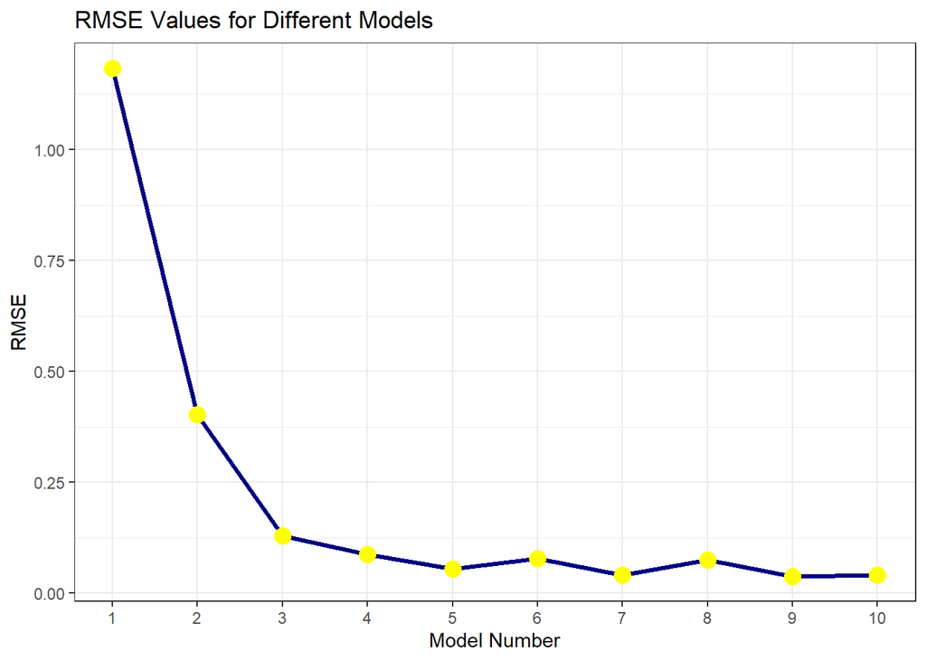

```r
purrr::map2_dfr(list(fit_lm1, fit_lm2, fit_lm3,
                     fit_lm4, fit_lm5, fit_lm6,
                     fit_lm7, fit_lm8, fit_lm9,fit_lm10),
                1:10,
                function(m, p, data_use){
                  list(fit_lm = p,
                       RMSE = modelr::rmse(m, data_use))
                },
                data_use = df_train) %>%
  ggplot(mapping = aes(x = fit_lm, y = RMSE)) +
  geom_line(size = 1.2, color = "navy") +
  geom_point(size = 4, color = "yellow") +
  scale_x_continuous(breaks = 1:10) +
  theme_bw() +
  labs(title = "RMSE Values for Different Models",
       x = "Model Number",
       y = "RMSE") +
  theme(panel.grid.minor.x = element_blank())
```

**R Squared for each model**

```r
tibble::tibble(
  lm_1 = modelr::rsquare(fit_lm1, df_train),
  lm_2 = modelr::rsquare(fit_lm2, df_train),
  lm_3 = modelr::rsquare(fit_lm3, df_train),
  lm_4 = modelr::rsquare(fit_lm4, df_train),
  lm_5 = modelr::rsquare(fit_lm5, df_train),
  lm_6 = modelr::rsquare(fit_lm6, df_train),
  lm_7 = modelr::rsquare(fit_lm7, df_train),
  lm_8 = modelr::rsquare(fit_lm8, df_train),
  lm_9 = modelr::rsquare(fit_lm9, df_train),
  lm_10 = modelr::rsquare(fit_lm10, df_train)
)
```

```
## # A tibble: 1 × 10
##    lm_1  lm_2  lm_3  lm_4  lm_5  lm_6  lm_7  lm_8  lm_9 lm_10
##   <dbl> <dbl> <dbl> <dbl> <dbl> <dbl> <dbl> <dbl> <dbl> <dbl>
## 1     0 0.885 0.988 0.995 0.998 0.996 0.999 0.996 0.999 0.999
```

```r
results_fit_lf %>%
  mutate(R_squared = c(modelr::rsquare(fit_lm1, df_train),
                       modelr::rsquare(fit_lm2, df_train),
                       modelr::rsquare(fit_lm3, df_train),
                       modelr::rsquare(fit_lm4, df_train),
                       modelr::rsquare(fit_lm5, df_train),
                       modelr::rsquare(fit_lm6, df_train),
                       modelr::rsquare(fit_lm7, df_train),
                       modelr::rsquare(fit_lm8, df_train),
                       modelr::rsquare(fit_lm9, df_train),
                       modelr::rsquare(fit_lm10, df_train))) %>%
  arrange(desc(R_squared))
```

```
## # A tibble: 10 × 3
##    fit_lm   RMSE R_squared
##     <int>  <dbl>     <dbl>
##  1      9 0.0387     0.999
##  2      7 0.0408     0.999
##  3     10 0.0415     0.999
##  4      5 0.0554     0.998
##  5      8 0.0759     0.996
##  6      6 0.0779     0.996
##  7      4 0.0877     0.995
##  8      3 0.129      0.988
##  9      2 0.402      0.885
## 10      1 1.18       0
```

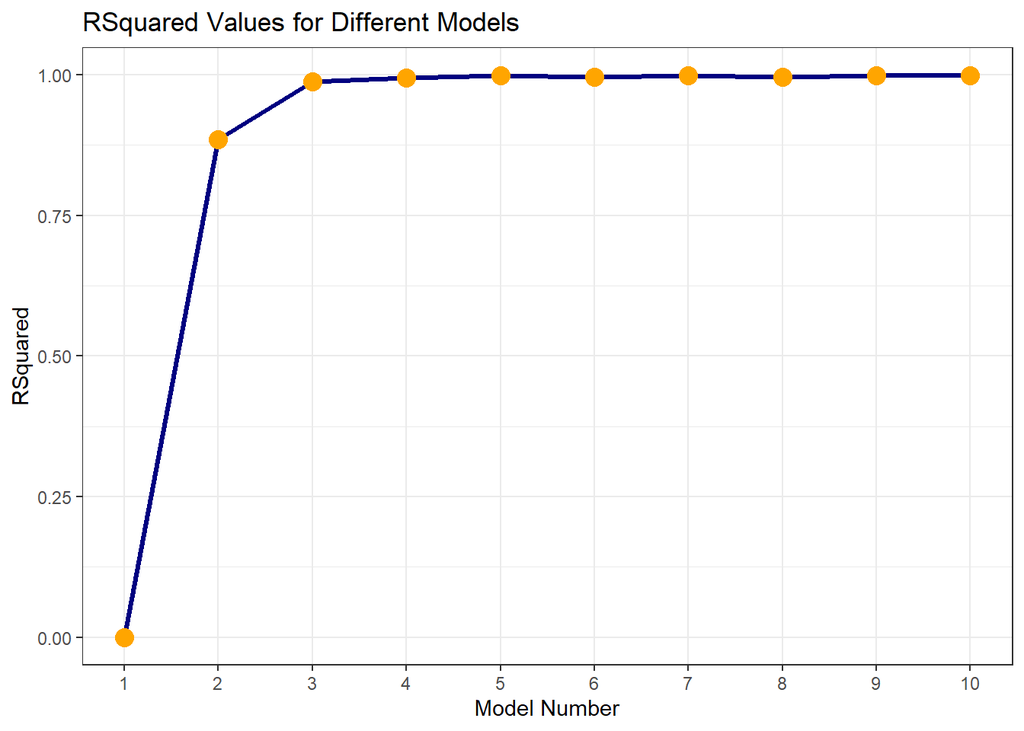

```r
results_fit_lf %>%
  mutate(R_squared = c(modelr::rsquare(fit_lm1, df_train),
                       modelr::rsquare(fit_lm2, df_train),
                       modelr::rsquare(fit_lm3, df_train),
                       modelr::rsquare(fit_lm4, df_train),
                       modelr::rsquare(fit_lm5, df_train),
                       modelr::rsquare(fit_lm6, df_train),
                       modelr::rsquare(fit_lm7, df_train),
                       modelr::rsquare(fit_lm8, df_train),
                       modelr::rsquare(fit_lm9, df_train),
                       modelr::rsquare(fit_lm10, df_train))) %>%
  ggplot(mapping = aes(x = fit_lm, y = R_squared)) +
  geom_line(size = 1.2,color="navy") +
  geom_point(size = 4,color="orange") +
  scale_x_continuous(breaks = 1:10) +
   labs(title = "RSquared Values for Different Models",
       x = "Model Number",
       y = "RSquared") +
  theme_bw() +
  theme(panel.grid.minor.x = element_blank())
```

The best model according to RMSE is the one with the smallest RMSE value. The best model according to R-squared is the highest R-squared value.For this application, the fit_lm9 has the lowest training set RMSE and the highest training set R-squared. Both performance metrics agree on the best model.

**Coefficient summaries for your top 3 models**

```r
summary(fit_lm9)
```

```
##
## Call:
## lm(formula = logit_response ~ (poly(R, 2) + poly(G, 2) + poly(B,
##     2) + Hue) * (Lightness + Saturation), data = df_train)
##
## Residuals:
##       Min        1Q    Median        3Q       Max
## -0.236808 -0.021681 -0.000584  0.020046  0.213288
##
## Coefficients:
##                                  Estimate Std. Error t value Pr(>|t|)
## (Intercept)                    -1.157e-01  6.753e-02  -1.713 0.087173 .
## poly(R, 2)1                     7.690e+00  3.383e-01  22.730  < 2e-16 ***
## poly(R, 2)2                     9.315e-01  1.763e-01   5.282 1.69e-07 ***
## poly(G, 2)1                     2.149e+01  5.829e-01  36.872  < 2e-16 ***
## poly(G, 2)2                     3.711e-01  2.666e-01   1.392 0.164353
## poly(B, 2)1                     1.370e+00  1.440e+00   0.951 0.341733
## poly(B, 2)2                    -1.293e+00  5.138e-01  -2.517 0.012044 *
## Hue                            -5.555e-03  9.673e-04  -5.743 1.37e-08 ***
## Lightnessdeep                  -1.278e-02  6.426e-02  -0.199 0.842466
## Lightnesslight                  7.142e-01  1.508e-01   4.737 2.61e-06 ***
## Lightnessmidtone                1.567e-01  6.910e-02   2.268 0.023606 *
## Lightnesspale                   1.779e+00  3.115e-01   5.712 1.62e-08 ***
## Lightnesssaturated              7.525e-02  6.590e-02   1.142 0.253917
## Lightnesssoft                   3.831e-01  8.204e-02   4.670 3.59e-06 ***
## Saturationgray                 -1.434e-02  2.010e-02  -0.713 0.475813
## Saturationmuted                 2.198e-03  1.633e-02   0.135 0.892989
## Saturationneutral              -6.828e-02  1.677e-02  -4.071 5.19e-05 ***
## Saturationpure                 -2.001e-02  1.714e-02  -1.168 0.243324
## Saturationshaded               -1.746e-02  1.600e-02  -1.091 0.275436
## Saturationsubdued              -3.013e-02  1.718e-02  -1.753 0.079947 .
## poly(R, 2)1:Lightnessdeep      -1.371e-01  3.161e-01  -0.434 0.664673
## poly(R, 2)2:Lightnessdeep       3.390e-01  1.776e-01   1.909 0.056687 .
## poly(R, 2)1:Lightnesslight      2.720e-01  3.743e+00   0.073 0.942087
## poly(R, 2)2:Lightnesslight      7.862e-01  1.856e+00   0.424 0.671912
## poly(R, 2)1:Lightnessmidtone   -2.208e+00  5.018e-01  -4.400 1.24e-05 ***
## poly(R, 2)2:Lightnessmidtone    1.347e+00  3.744e-01   3.598 0.000343 ***
## poly(R, 2)1:Lightnesspale      -1.647e+01  1.023e+01  -1.610 0.107823
## poly(R, 2)2:Lightnesspale       9.158e+00  4.442e+00   2.062 0.039606 *
## poly(R, 2)1:Lightnesssaturated -1.121e+00  3.390e-01  -3.308 0.000987 ***
```

[output cut: 66 more lines]

```
## Hue:Lightnesspale               5.425e-03  9.931e-04   5.463 6.43e-08 ***
## Hue:Lightnesssaturated          4.458e-03  9.240e-04   4.825 1.71e-06 ***
## Hue:Lightnesssoft               4.325e-03  1.045e-03   4.140 3.87e-05 ***
## Hue:Saturationgray             -9.630e-04  1.088e-03  -0.885 0.376386
## Hue:Saturationmuted            -6.132e-04  8.153e-04  -0.752 0.452209
## Hue:Saturationneutral           2.468e-03  9.248e-04   2.668 0.007788 **
## Hue:Saturationpure              2.035e-03  8.126e-04   2.504 0.012499 *
## Hue:Saturationshaded           -6.235e-04  8.576e-04  -0.727 0.467401
## Hue:Saturationsubdued           2.609e-04  8.940e-04   0.292 0.770473
## ---
## Signif. codes:  0 '***' 0.001 '**' 0.01 '*' 0.05 '.' 0.1 ' ' 1
##
## Residual standard error: 0.04134 on 731 degrees of freedom
## Multiple R-squared:  0.9989, Adjusted R-squared:  0.9988
## F-statistic:  6640 on 103 and 731 DF,  p-value: < 2.2e-16
```

```r
summary(fit_lm7)
```

```
##
## Call:
## lm(formula = logit_response ~ (R + G + B + Hue)^2 * (Lightness +
##     Saturation), data = df_train)
##
## Residuals:
##       Min        1Q    Median        3Q       Max
## -0.233973 -0.023247 -0.001102  0.022124  0.201412
##
## Coefficients:
##                            Estimate Std. Error t value Pr(>|t|)
## (Intercept)              -4.782e+00  3.131e-01 -15.271  < 2e-16 ***
## R                         8.432e-03  1.890e-03   4.461 9.53e-06 ***
## G                         1.737e-02  2.291e-03   7.582 1.10e-13 ***
## B                         9.959e-03  2.059e-03   4.837 1.63e-06 ***
## Hue                       8.036e-03  1.264e-02   0.636 0.525200
## Lightnessdeep             4.939e-01  2.378e-01   2.077 0.038131 *
## Lightnesslight            1.102e+01  1.708e+00   6.450 2.10e-10 ***
## Lightnessmidtone          3.742e+00  4.747e-01   7.883 1.25e-14 ***
## Lightnesspale             2.460e+01  3.356e+00   7.330 6.45e-13 ***
## Lightnesssaturated        2.235e+00  3.115e-01   7.175 1.86e-12 ***
## Lightnesssoft             6.570e+00  7.647e-01   8.591  < 2e-16 ***
## Saturationgray           -1.148e-01  2.797e-01  -0.411 0.681526
## Saturationmuted          -3.031e-01  2.408e-01  -1.259 0.208560
## Saturationneutral        -1.512e-01  2.568e-01  -0.589 0.556208
## Saturationpure           -1.225e-01  3.184e-01  -0.385 0.700495
## Saturationshaded         -6.223e-02  2.535e-01  -0.245 0.806191
## Saturationsubdued        -3.923e-01  2.611e-01  -1.503 0.133386
## R:G                      -1.634e-05  6.036e-06  -2.706 0.006967 **
## R:B                      -1.741e-05  8.436e-06  -2.064 0.039398 *
## R:Hue                    -3.375e-05  6.661e-05  -0.507 0.612528
## G:B                      -1.677e-05  1.342e-05  -1.249 0.211982
## G:Hue                     4.219e-05  5.500e-05   0.767 0.443352
## B:Hue                    -1.305e-04  7.460e-05  -1.749 0.080692 .
## R:Lightnessdeep          -7.922e-04  9.529e-04  -0.831 0.406072
## R:Lightnesslight         -3.478e-02  7.982e-03  -4.357 1.52e-05 ***
## R:Lightnessmidtone       -1.259e-02  2.093e-03  -6.016 2.90e-09 ***
## R:Lightnesspale          -6.586e-02  1.990e-02  -3.309 0.000985 ***
## R:Lightnesssaturated     -8.552e-03  1.366e-03  -6.260 6.76e-10 ***
## R:Lightnesssoft          -1.965e-02  3.593e-03  -5.467 6.39e-08 ***
```

[output cut: 105 more lines]

```
## B:Hue:Lightnesspale      -2.002e-04  1.539e-04  -1.301 0.193803
## B:Hue:Lightnesssaturated  1.223e-04  6.208e-05   1.971 0.049152 *
## B:Hue:Lightnesssoft      -7.236e-05  8.642e-05  -0.837 0.402694
## B:Hue:Saturationgray      2.232e-04  1.531e-04   1.458 0.145257
## B:Hue:Saturationmuted     3.204e-05  5.489e-05   0.584 0.559617
## B:Hue:Saturationneutral   1.738e-04  8.440e-05   2.059 0.039866 *
## B:Hue:Saturationpure     -4.786e-05  6.073e-05  -0.788 0.430981
## B:Hue:Saturationshaded    1.730e-05  7.242e-05   0.239 0.811232
## B:Hue:Saturationsubdued   2.092e-04  6.741e-05   3.103 0.001996 **
## ---
## Signif. codes:  0 '***' 0.001 '**' 0.01 '*' 0.05 '.' 0.1 ' ' 1
##
## Residual standard error: 0.04486 on 692 degrees of freedom
## Multiple R-squared:  0.9988, Adjusted R-squared:  0.9986
## F-statistic:  4089 on 142 and 692 DF,  p-value: < 2.2e-16
```

```r
summary(fit_lm10)
```

```
##
## Call:
## lm(formula = logit_response ~ poly(R, 2) * poly(G, 2) + poly(R,
##     2) * poly(B, 2) + poly(R, 2) * poly(Hue, 2) + poly(G, 2) *
##     poly(B, 2) + poly(G, 2) * poly(Hue, 2) + poly(B, 2) * poly(Hue,
##     2), data = df_train)
##
## Residuals:
##      Min       1Q   Median       3Q      Max
## -0.16367 -0.02474 -0.00069  0.02245  0.31932
##
## Coefficients:
##                            Estimate Std. Error t value Pr(>|t|)
## (Intercept)                -0.11322    0.03094  -3.660 0.000269 ***
## poly(R, 2)1                 7.45175    0.21589  34.516  < 2e-16 ***
## poly(R, 2)2                 2.12977    0.21115  10.086  < 2e-16 ***
## poly(G, 2)1                21.59936    0.69196  31.215  < 2e-16 ***
## poly(G, 2)2                 3.08758    0.41282   7.479 1.96e-13 ***
## poly(B, 2)1                 4.44560    0.32747  13.576  < 2e-16 ***
## poly(B, 2)2                 0.46097    0.23928   1.926 0.054396 .
## poly(Hue, 2)1              -0.31446    0.17019  -1.848 0.065011 .
## poly(Hue, 2)2               0.12105    0.13405   0.903 0.366756
## poly(R, 2)1:poly(G, 2)1   -29.74917   11.29750  -2.633 0.008620 **
## poly(R, 2)2:poly(G, 2)1     4.81960    5.08359   0.948 0.343380
## poly(R, 2)1:poly(G, 2)2    50.95265    4.61111  11.050  < 2e-16 ***
## poly(R, 2)2:poly(G, 2)2    14.02894    2.07526   6.760 2.65e-11 ***
## poly(R, 2)1:poly(B, 2)1   -22.28583    6.91076  -3.225 0.001312 **
## poly(R, 2)2:poly(B, 2)1    -4.68547    4.72200  -0.992 0.321368
## poly(R, 2)1:poly(B, 2)2    -2.31862    3.82405  -0.606 0.544470
## poly(R, 2)2:poly(B, 2)2     0.61523    2.23411   0.275 0.783094
## poly(R, 2)1:poly(Hue, 2)1   4.62485    7.55522   0.612 0.540618
## poly(R, 2)2:poly(Hue, 2)1  -1.99810    3.82297  -0.523 0.601357
## poly(R, 2)1:poly(Hue, 2)2  -1.49031    7.69884  -0.194 0.846557
## poly(R, 2)2:poly(Hue, 2)2  13.33497    4.33623   3.075 0.002175 **
## poly(G, 2)1:poly(B, 2)1    16.64017   18.83925   0.883 0.377354
## poly(G, 2)2:poly(B, 2)1    41.32532    6.84856   6.034 2.44e-09 ***
## poly(G, 2)1:poly(B, 2)2     6.61622    5.77599   1.145 0.252357
## poly(G, 2)2:poly(B, 2)2    13.39877    1.71607   7.808 1.82e-14 ***
## poly(G, 2)1:poly(Hue, 2)1  -3.62347    8.17173  -0.443 0.657585
## poly(G, 2)2:poly(Hue, 2)1  -4.85179    3.36002  -1.444 0.149136
## poly(G, 2)1:poly(Hue, 2)2 -23.34096   10.74431  -2.172 0.030118 *
## poly(G, 2)2:poly(Hue, 2)2  -3.60182    2.47681  -1.454 0.146277
## poly(B, 2)1:poly(Hue, 2)1   5.86864   11.57234   0.507 0.612205
## poly(B, 2)2:poly(Hue, 2)1   0.95693    4.14122   0.231 0.817317
## poly(B, 2)1:poly(Hue, 2)2  16.40921    9.53810   1.720 0.085748 .
## poly(B, 2)2:poly(Hue, 2)2  -2.04294    3.36713  -0.607 0.544202
## ---
## Signif. codes:  0 '***' 0.001 '**' 0.01 '*' 0.05 '.' 0.1 ' ' 1
##
## Residual standard error: 0.04234 on 802 degrees of freedom
## Multiple R-squared:  0.9988, Adjusted R-squared:  0.9987
## F-statistic: 2.036e+04 on 32 and 802 DF,  p-value: < 2.2e-16
```

[figure not shown]

```r
library(coefplot)


multi_coef_plot <- coefplot::multiplot(fit_lm9, fit_lm7, fit_lm10, dodgeHeight = 0.9) +
  theme_bw() +
  labs(title = "Coefficient Comparison of Top 3 Models",
       y = "Coefficient Estimate", x = "Predictors") +
  theme(axis.text.y = element_text(angle = 40, hjust = 1, size = 8),
        legend.position = "bottom", # Place legend at the bottom
        plot.title = element_text(hjust = 0.5), # Center the plot title
        axis.title.x = element_text(vjust = -0.5)) # Adjust x-axis title


print(multi_coef_plot)
```

```r
check_significance <- function(model) {
  # Extracting the summary
  model_summary <- summary(model)
  # Getting the coefficients
  coefficients <- model_summary$coefficients
  # Checking for significance (p-value < 0.05)
  significant_terms <- rownames(coefficients)[coefficients[, "Pr(>|t|)"] < 0.05]
  return(significant_terms)
}


significant_inputs_lm9 <- check_significance(fit_lm9)
significant_inputs_lm7 <- check_significance(fit_lm7)
significant_inputs_lm10 <- check_significance(fit_lm10)


print(significant_inputs_lm9)
```

```
##  [1] "poly(R, 2)1"                    "poly(R, 2)2"
##  [3] "poly(G, 2)1"                    "poly(B, 2)2"
##  [5] "Hue"                            "Lightnesslight"
##  [7] "Lightnessmidtone"               "Lightnesspale"
##  [9] "Lightnesssoft"                  "Saturationneutral"
## [11] "poly(R, 2)1:Lightnessmidtone"   "poly(R, 2)2:Lightnessmidtone"
## [13] "poly(R, 2)2:Lightnesspale"      "poly(R, 2)1:Lightnesssaturated"
## [15] "poly(R, 2)2:Lightnesssaturated" "poly(R, 2)1:Lightnesssoft"
## [17] "poly(R, 2)2:Lightnesssoft"      "poly(R, 2)1:Saturationneutral"
## [19] "poly(R, 2)2:Saturationpure"     "poly(R, 2)2:Saturationshaded"
## [21] "poly(G, 2)2:Lightnessdeep"      "poly(G, 2)1:Lightnesslight"
## [23] "poly(G, 2)2:Lightnesslight"     "poly(G, 2)1:Lightnessmidtone"
## [25] "poly(G, 2)2:Lightnessmidtone"   "poly(G, 2)1:Lightnesspale"
## [27] "poly(G, 2)2:Lightnesspale"      "poly(G, 2)2:Lightnesssaturated"
## [29] "poly(G, 2)1:Lightnesssoft"      "poly(G, 2)2:Lightnesssoft"
## [31] "poly(G, 2)2:Saturationgray"     "poly(G, 2)1:Saturationmuted"
## [33] "poly(G, 2)2:Saturationmuted"    "poly(G, 2)2:Saturationneutral"
## [35] "poly(G, 2)2:Saturationpure"     "poly(G, 2)1:Saturationshaded"
## [37] "poly(G, 2)1:Saturationsubdued"  "poly(G, 2)2:Saturationsubdued"
## [39] "poly(B, 2)2:Lightnessdeep"      "poly(B, 2)2:Lightnesslight"
## [41] "poly(B, 2)2:Lightnessmidtone"   "poly(B, 2)2:Lightnesspale"
## [43] "poly(B, 2)2:Lightnesssaturated" "poly(B, 2)2:Lightnesssoft"
## [45] "poly(B, 2)2:Saturationmuted"    "Hue:Lightnessdeep"
## [47] "Hue:Lightnesslight"             "Hue:Lightnessmidtone"
## [49] "Hue:Lightnesspale"              "Hue:Lightnesssaturated"
## [51] "Hue:Lightnesssoft"              "Hue:Saturationneutral"
## [53] "Hue:Saturationpure"
```

```r
print(significant_inputs_lm7)
```

```
##  [1] "(Intercept)"              "R"
##  [3] "G"                        "B"
##  [5] "Lightnessdeep"            "Lightnesslight"
##  [7] "Lightnessmidtone"         "Lightnesspale"
##  [9] "Lightnesssaturated"       "Lightnesssoft"
## [11] "R:G"                      "R:B"
## [13] "R:Lightnesslight"         "R:Lightnessmidtone"
## [15] "R:Lightnesspale"          "R:Lightnesssaturated"
## [17] "R:Lightnesssoft"          "G:Lightnessdeep"
## [19] "G:Lightnesslight"         "G:Lightnessmidtone"
## [21] "G:Lightnesspale"          "G:Lightnesssaturated"
## [23] "G:Lightnesssoft"          "G:Saturationgray"
## [25] "G:Saturationneutral"      "G:Saturationsubdued"
## [27] "B:Lightnessmidtone"       "B:Lightnesssaturated"
## [29] "B:Lightnesssoft"          "B:Saturationmuted"
## [31] "B:Saturationsubdued"      "Hue:Lightnessmidtone"
## [33] "Hue:Lightnesssaturated"   "R:G:Lightnessdeep"
## [35] "R:G:Lightnesslight"       "R:G:Lightnessmidtone"
## [37] "R:G:Lightnesspale"        "R:G:Lightnesssaturated"
## [39] "R:G:Lightnesssoft"        "R:G:Saturationsubdued"
## [41] "R:B:Lightnesssaturated"   "G:B:Lightnesslight"
## [43] "G:B:Lightnessmidtone"     "G:B:Lightnesspale"
## [45] "G:B:Lightnesssoft"        "G:Hue:Lightnesslight"
## [47] "G:Hue:Lightnessmidtone"   "G:Hue:Lightnesssaturated"
## [49] "G:Hue:Lightnesssoft"      "G:Hue:Saturationneutral"
## [51] "B:Hue:Lightnesssaturated" "B:Hue:Saturationneutral"
## [53] "B:Hue:Saturationsubdued"
```

```r
print(significant_inputs_lm10)
```

```
##  [1] "(Intercept)"               "poly(R, 2)1"
##  [3] "poly(R, 2)2"               "poly(G, 2)1"
##  [5] "poly(G, 2)2"               "poly(B, 2)1"
##  [7] "poly(R, 2)1:poly(G, 2)1"   "poly(R, 2)1:poly(G, 2)2"
##  [9] "poly(R, 2)2:poly(G, 2)2"   "poly(R, 2)1:poly(B, 2)1"
## [11] "poly(R, 2)2:poly(Hue, 2)2" "poly(G, 2)2:poly(B, 2)1"
## [13] "poly(G, 2)2:poly(B, 2)2"   "poly(G, 2)1:poly(Hue, 2)2"
```

The important inputs appear to be the interactions between the polynomial terms of R, G, and B, interactions with Hue and different categories of lightness and saturation, and the categorical variables representing different levels of lightness and saturation. These inputs have p-values less than 0.05, indicating that they are statistically significant in predicting the response variable.

## Part iib: Linear Regression– iiB) Bayesian Linear models

**Logit Transform**

```r
logit <- function(p) {
  log(p / (1 - p))
}

df_train$logit_response <- logit((df_train$response - 0) / (100 - 0))
```

1.Interaction terms between the polynomial-transformed continuous variables and the categorical variables

```r
##Best Model
X01 <- model.matrix(logit_response ~ (poly(R, 2) + poly(G, 2) + poly(B, 2) + Hue) * (Lightness + Saturation), data = df_train)

info_01_weak <- list(
  yobs = df_train$logit_response,
  design_matrix = X01,
  mu_beta = 0,
  tau_beta = 50,
  sigma_rate = 1
)

info_01_strong <- list(
  yobs = df_train$logit_response,
  design_matrix = X01,
  mu_beta = 0,
  tau_beta = 1,
  sigma_rate = 1
)

info_01_very_strong <- list(
  yobs = df_train$logit_response,
  design_matrix = X01,
  mu_beta = 0,
  tau_beta = 1/50,
  sigma_rate = 1
)
```

2.All categorical and continuous variables – linear additive

Choosing a model with all categorical and continuous variables and linear additive features simplifies the analysis by assuming a linear relationship between predictors and the log-odds of the response. This approach is interpretable, efficient for large datasets, and helps identify the impact of each variable on the outcome.

```r
X02 <- model.matrix(logit_response ~ R + G + B + Hue + Lightness + Saturation, data = df_train)

info_02_weak <- list(
  yobs = df_train$logit_response,
  design_matrix = X02,
  mu_beta = 0,
  tau_beta = 50,
  sigma_rate = 1
)

info_02_strong <- list(
  yobs = df_train$logit_response,
  design_matrix = X02,
  mu_beta = 0,
  tau_beta = 1,
  sigma_rate = 1
)

info_02_very_strong <- list(
  yobs = df_train$logit_response,
  design_matrix = X02,
  mu_beta = 0,
  tau_beta = 1/50,
  sigma_rate = 1
)
```

The log-posterior function to calculate the mean trend, mu, using matrix math between the design matrix and the unknown β column vector.

```r
lm_logpost <- function(unknowns, my_info)
{
  # specify the number of unknown beta parameters
  length_beta <- ncol(my_info$design_matrix)

  # extract the beta parameters from the `unknowns` vector
  beta_v <- unknowns[1:length_beta]

  # extract the unbounded noise parameter, varphi
  lik_varphi <- unknowns[length_beta + 1]

  # back-transform from varphi to sigma
  lik_sigma <- exp(lik_varphi)

  # extract design matrix
  X <- my_info$design_matrix

  # calculate the linear predictor
  mu <- as.vector( X %*% as.matrix(beta_v) )

  # evaluate the log-likelihood
  log_lik <- sum(dnorm(x = my_info$yobs,
                       mean = mu,
                       sd = lik_sigma,
                       log = TRUE))

  # evaluate the log-prior
  log_prior_beta <- sum(dnorm(x = beta_v,
                              mean = my_info$mu_beta,
                              sd = my_info$tau_beta,
                              log = TRUE))

  log_prior_sigma <- dexp(x = lik_sigma,
                          rate = my_info$sigma_rate,
                          log = TRUE)

  # add the mean trend prior and noise prior together
  log_prior <- log_prior_beta + log_prior_sigma

  # account for the transformation
  log_derive_adjust <- lik_varphi

  # sum together
  log_lik + log_prior + log_derive_adjust
}
```

my_laplace() function executes the laplace approximation and returns the object consisting of the posterior mode, posterior covariance matrix, and the log-evidence.

```r
my_laplace <- function(start_guess, logpost_func, ...)
{
  # code adapted from the `LearnBayes`` function `laplace()`
  fit <- optim(start_guess,
               logpost_func,
               gr = NULL,
               ...,
               method = "BFGS",
               hessian = TRUE,
               control = list(fnscale = -1, maxit = 1001))

  mode <- fit$par
  post_var_matrix <- -solve(fit$hessian)
  p <- length(mode)
  int <- p/2 * log(2 * pi) + 0.5 * log(det(post_var_matrix)) + logpost_func(mode, ...)
  # package all of the results into a list
  list(mode = mode,
       var_matrix = post_var_matrix,
       log_evidence = int,
       converge = ifelse(fit$convergence == 0,
                         "YES",
                         "NO"),
       iter_counts = as.numeric(fit$counts[1]))
}
```

Execute the Laplace Approximation for the model 1 formulation and the model 2 formulation

```r
laplace_01_weak <- my_laplace(rep(0, ncol(X01)+1), lm_logpost, info_01_weak)
laplace_02_weak <- my_laplace(rep(0, ncol(X02)+1), lm_logpost, info_02_weak)

laplace_01_weak$converge
```

```
## [1] "YES"
```

```r
laplace_02_weak$converge
```

```
## [1] "YES"
```

```r
laplace_01_strong <- my_laplace(rep(0, ncol(X01) + 1), lm_logpost, info_01_strong)
laplace_02_strong <- my_laplace(rep(0, ncol(X02) + 1), lm_logpost, info_02_strong)

convergence_results <- purrr::map(list(laplace_01_strong, laplace_02_strong), ~ .x$converge)
convergence_results_char <- purrr::map_chr(convergence_results, as.character)

convergence_results_char
```

```
## [1] "YES" "YES"
```

```r
laplace_01_very_strong <- my_laplace(rep(0, ncol(X01) + 1), lm_logpost, info_01_very_strong)
laplace_02_very_strong <- my_laplace(rep(0, ncol(X02) + 1), lm_logpost, info_02_very_strong)

convergence_results <- purrr::map_chr(list(laplace_01_very_strong, laplace_02_very_strong), pluck, "converge")
convergence_results
```

```
## [1] "YES" "YES"
```

Use the Bayes Factor to identify the better of the models.

```r
evidence_ratio <- exp(laplace_01_weak$log_evidence) / exp(laplace_02_weak$log_evidence)

log_evidence_diff <- laplace_01_weak$log_evidence - laplace_02_weak$log_evidence
evidence_exp_difference <- exp(log_evidence_diff)

evidence_ratio
```

```
## [1] Inf
```

```r
evidence_exp_difference
```

```
## [1] 1.185846e+74
```

```r
log_evidence_ratio_strong <- laplace_01_strong$log_evidence - laplace_02_strong$log_evidence
log_evidence_ratio_very_strong <- laplace_01_very_strong$log_evidence - laplace_02_very_strong$log_evidence
log_bayes_factor <- laplace_01_strong$log_evidence - laplace_02_very_strong$log_evidence


evidence_ratio_strong <- exp(log_evidence_ratio_strong)
evidence_ratio_very_strong <- exp(log_evidence_ratio_very_strong)
bayes_factor <- exp(log_bayes_factor)

evidence_ratio_strong
```

```
## [1] 2.493017e+58
```

```r
evidence_ratio_very_strong
```

```
## [1] 0
```

```r
bayes_factor
```

```
## [1] Inf
```

An evidence ratio of `Inf` indicates strong evidence in favor of the first model over the second model. This does not necessarily mean overfitting, but rather that the first model is substantially more supported by the data according to the Bayes Factor. Overfitting is more related to the complexity of the model relative to the amount of data available. If the first model is more complex and still has significantly stronger support, it suggests that the complexity is justified by the data. However, it’s always a good idea to further validate the model’s performance on independent data to ensure it generalizes well.

**Visualize the regression coefficient posterior summary statistics for your best model.**

```r
viz_post_coefs <- function(post_means, post_sds, xnames)
{
  tibble::tibble(
    mu = post_means,
    sd = post_sds,
    x = xnames
  ) %>%
    mutate(x = factor(x, levels = xnames)) %>%
    ggplot(mapping = aes(x = x),color="red") +
    geom_hline(yintercept = 0, color = 'black', linetype = 'dashed') +
    geom_point(mapping = aes(y = mu),color="blue") +
    geom_linerange(mapping = aes(ymin = mu - 2 * sd,
                                 ymax = mu + 2 * sd,
                                 group = x)) +
    labs(x = 'feature', y = 'coefficient value') +
    coord_flip() +
    theme_bw()
}
```

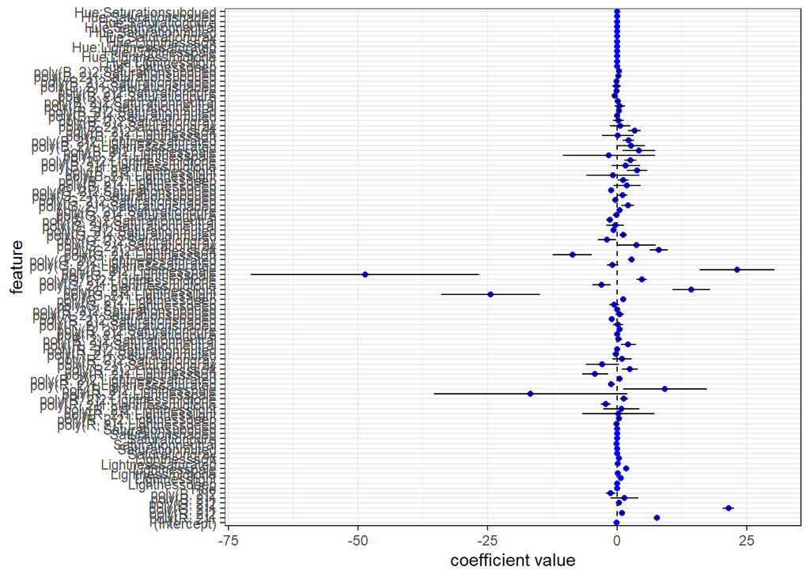

```r
viz_post_coefs(laplace_01_weak$mode[1:ncol(X01)],
               sqrt(diag(laplace_01_weak$var_matrix)[1:ncol(X01)]),
               colnames(X01))
```

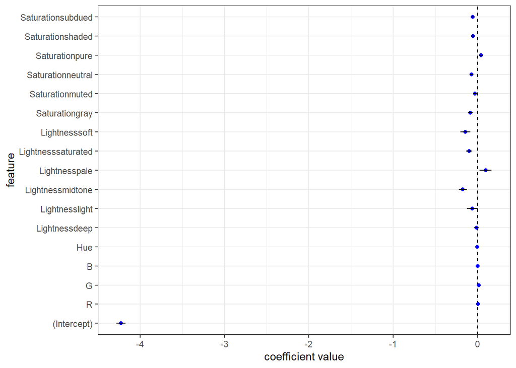

```r
viz_post_coefs(laplace_02_weak$mode[1:ncol(X02)],
               sqrt(diag(laplace_02_weak$var_matrix)[1:ncol(X02)]),
               colnames(X02))
```

Calculate the MLE of 𝜎 using the lm() function

```r
lm_09 <- lm(logit_response ~ (poly(R, 2) + poly(G, 2) + poly(B, 2) + Hue) * (Lightness + Saturation), data = df_train)
mle_sigma <- summary(lm_09)$sigma
mle_sigma
```

```
## [1] 0.04133555
```

**The posterior uncertainty on the likelihood noise (residual error), σ, for your linear model lm_09 and compare it with the maximum likelihood estimate (MLE)**

```r
library(rstanarm)
stan_fit <- stan_glm(logit_response ~ (poly(R, 2) + poly(G, 2) + poly(B, 2) + Hue) * (Lightness + Saturation),
                     data = df_train, family = gaussian())
posterior_samples <- as.data.frame(stan_fit)
sigma_posterior_mean <- mean(posterior_samples$sigma)
sigma_posterior_ci <- quantile(posterior_samples$sigma, probs = c(0.025, 0.975))


cat("MLE of sigma:", mle_sigma, "\n")
```

```
## MLE of sigma: 0.04133555
```

```r
cat("Posterior mean of sigma:", sigma_posterior_mean, "\n")
```

```
## Posterior mean of sigma: 0.04141486
```

```r
cat("95% credible interval for sigma:", sigma_posterior_ci, "\n")
```

```
## 95% credible interval for sigma: 0.03936146 0.04363083
```

```r
prob_below_mle <- mean(pnorm(mle_sigma, mean = sigma_posterior_mean, sd = sd(posterior_samples$sigma)))
cat("Probability that sigma is below the MLE:", prob_below_mle, "\n")
```

```
## Probability that sigma is below the MLE: 0.4709212
```

## Part iic: Linear Regression - Linear models Predictions

Model 1:

```r
Model1 <- lm(logit_response ~ (R + G + B + Hue)^2 * (Lightness + Saturation), data = df_train)
```

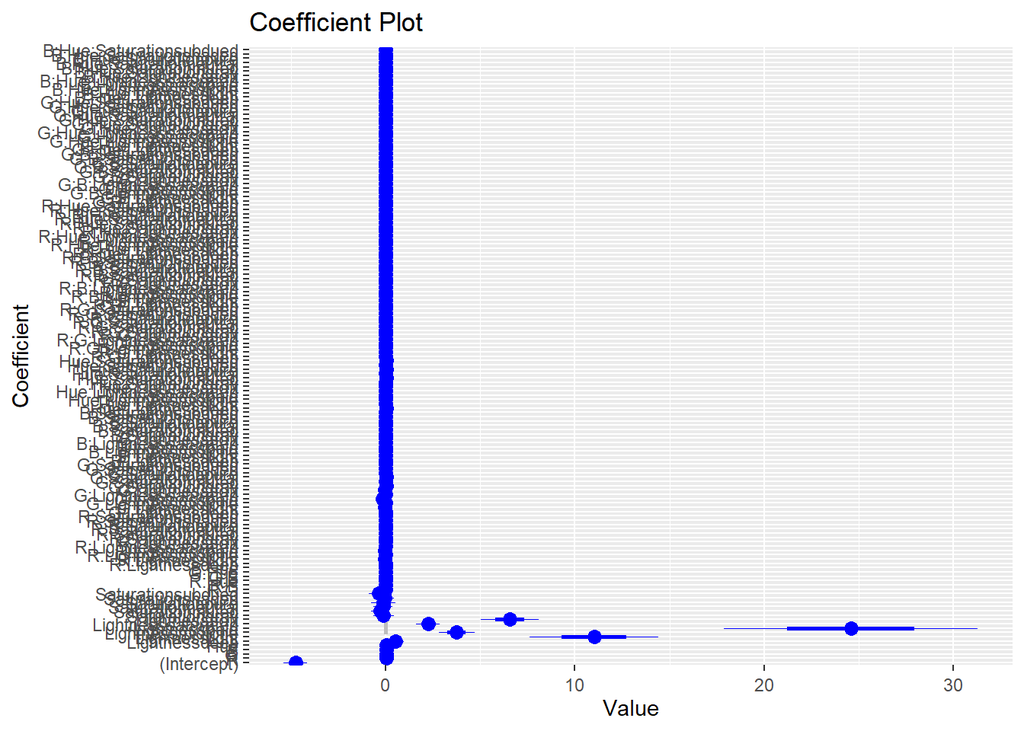

```r
library(coefplot)
coefplot(Model1)
```

Model 2:

```r
Model2 <- lm(logit_response ~ (poly(R, 2) + poly(G, 2) + poly(B, 2) + Hue) * (Lightness + Saturation), data = df_train)
```

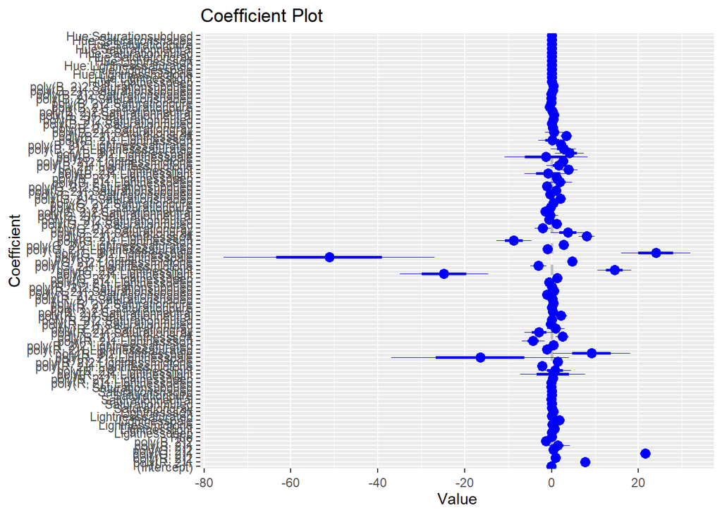

```r
coefplot(Model2)
```

**Best model considering training set only performance metrics**

```r
extract_model_metrics <- function(model, model_name) {
  broom::glance(model) %>% dplyr::mutate(model_name = model_name)
}
models <- list(Model1,Model2)
model_names <- c("Model1", "Model2")
model_metrics <- purrr::map2_dfr(models, model_names, extract_model_metrics)
glimpse(model_metrics)
```

```
## Rows: 2
## Columns: 13
## $ r.squared     <dbl> 0.9988095, 0.9989323
## $ adj.r.squared <dbl> 0.9985652, 0.9987819
## $ sigma         <dbl> 0.04486076, 0.04133555
## $ statistic     <dbl> 4088.665, 6640.055
## $ p.value       <dbl> 0, 0
## $ df            <dbl> 142, 103
## $ logLik        <dbl> 1485.612, 1531.058
## $ AIC           <dbl> -2683.224, -2852.117
## $ BIC           <dbl> -2002.474, -2355.736
## $ deviance      <dbl> 1.392641, 1.249007
## $ df.residual   <int> 692, 731
## $ nobs          <int> 835, 835
## $ model_name    <chr> "Model1", "Model2"
```

```r
best_r_squared <- model_metrics %>%
                  dplyr::filter(r.squared == max(r.squared)) %>%
                  dplyr::pull(model_name)

best_AIC <- model_metrics %>%
            dplyr::filter(AIC == min(AIC)) %>%
            dplyr::pull(model_name)

best_BIC <- model_metrics %>%
            dplyr::filter(BIC == min(BIC)) %>%
            dplyr::pull(model_name)

best_r_squared
```

```
## [1] "Model2"
```

```r
best_AIC
```

```
## [1] "Model2"
```

```r
best_BIC
```

```
## [1] "Model2"
```

**Define a prediction or visualization test grid**

```r
unique_lightness <- unique(df_train$Lightness,2)
unique_saturation <- unique(df_train$Saturation,2)

viz_grid <- expand.grid(
  R = seq(min(df_train$R), max(df_train$R), length.out = 2),
  G = seq(min(df_train$G), max(df_train$G), length.out = 2),
  B = seq(min(df_train$B), max(df_train$B), length.out = 2),
  Hue = seq(min(df_train$Hue), max(df_train$Hue), length.out = 2),
  Lightness = unique_lightness,
  Saturation = unique_saturation
)
```

```r
tidy_predict <- function(mod, xnew)
{
  pred_df <- predict(mod, xnew, interval = "confidence") %>%
    as.data.frame() %>% tibble::as_tibble() %>%
    dplyr::select(pred = fit, ci_lwr = lwr, ci_upr = upr) %>%
    bind_cols(predict(mod, xnew, interval = 'prediction') %>%
                as.data.frame() %>% tibble::as_tibble() %>%
                dplyr::select(pred_lwr = lwr, pred_upr = upr))

  xnew %>% bind_cols(pred_df)
}
```

```r
pred_Model1 <- tidy_predict(Model1, viz_grid)
pred_Model1
```

```
##       R   G   B Hue Lightness Saturation          pred        ci_lwr
## 1     0  58  47   1      dark     bright  -3.347858022 -3.904033e+00
## 2   255  58  47   1      dark     bright  -1.656640304 -1.941743e+00
## 3     0 241  47   1      dark     bright  -0.305738680 -1.181491e+00
## 4   255 241  47   1      dark     bright   0.623173986  2.767322e-01
## 5     0  58 238   1      dark     bright  -1.656396550 -2.602833e+00
## 6   255  58 238   1      dark     bright  -0.813217544 -1.308032e+00
## 7     0 241 238   1      dark     bright   0.799538972 -3.282281e-01
## 8   255 241 238   1      dark     bright   0.880412926  1.698742e-01
## 9     0  58  47  36      dark     bright  -3.195636812 -3.564631e+00
## 10  255  58  47  36      dark     bright  -1.805643122 -2.284991e+00
## 11    0 241  47  36      dark     bright   0.116691892 -5.855037e-01
## 12  255 241  47  36      dark     bright   0.744380530  3.443321e-01
## 13    0  58 238  36      dark     bright  -2.376566111 -2.675709e+00
## 14  255  58 238  36      dark     bright  -1.834611134 -2.431486e+00
```

[output cut: 1555 more lines]

```r
pred_Model2 <- tidy_predict(Model2, viz_grid)
pred_Model2
```

```
##       R   G   B Hue Lightness Saturation         pred       ci_lwr       ci_upr
## 1     0  58  47   1      dark     bright -2.757406682 -2.836539902 -2.678273463
## 2   255  58  47   1      dark     bright -1.688076212 -1.760333821 -1.615818604
## 3     0 241  47   1      dark     bright -0.065530478 -0.215464436  0.084403480
## 4   255 241  47   1      dark     bright  1.003799992  0.881174351  1.126425633
## 5     0  58 238   1      dark     bright -2.530476757 -2.833693359 -2.227260154
## 6   255  58 238   1      dark     bright -1.461146287 -1.753867136 -1.168425437
## 7     0 241 238   1      dark     bright  0.161399448 -0.184866720  0.507665615
## 8   255 241 238   1      dark     bright  1.230729918  0.903249831  1.558210004
## 9     0  58  47  36      dark     bright -2.951833968 -3.044174819 -2.859493116
## 10  255  58  47  36      dark     bright -1.882503498 -1.993768820 -1.771238175
## 11    0 241  47  36      dark     bright -0.259957763 -0.401014531 -0.118900996
## 12  255 241  47  36      dark     bright  0.809372706  0.677661236  0.941084177
## 13    0  58 238  36      dark     bright -2.724904042 -3.001445544 -2.448362540
## 14  255  58 238  36      dark     bright -1.655573572 -1.929643697 -1.381503447
```

[output cut: 1555 more lines]

To visualize the predictive trends as per the provided style, R is used as the primary input for the x-axis and another input Lightness as the secondary input for faceting.

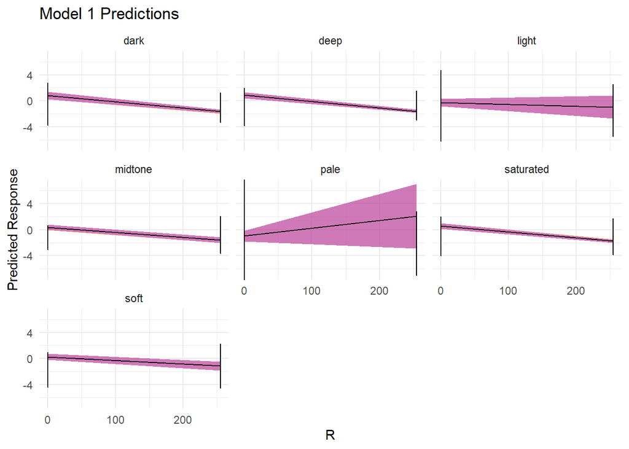

```r
pred_Model1 %>%
  ggplot(aes(x = R, y = pred)) +
  geom_ribbon(aes(ymin = pred_lwr, ymax = pred_upr), fill = "orange", alpha = 0.5) +
  geom_ribbon(aes(ymin = ci_lwr, ymax = ci_upr), fill = "purple", alpha = 0.5) +
  geom_line() +
  coord_cartesian(ylim = c(-7, 7)) +
  facet_wrap(~Lightness) +
  labs(title = "Model 1 Predictions",  # Adjust the title to match the model number
       x = "R",
       y = "Predicted Response") +
  theme_minimal()
```

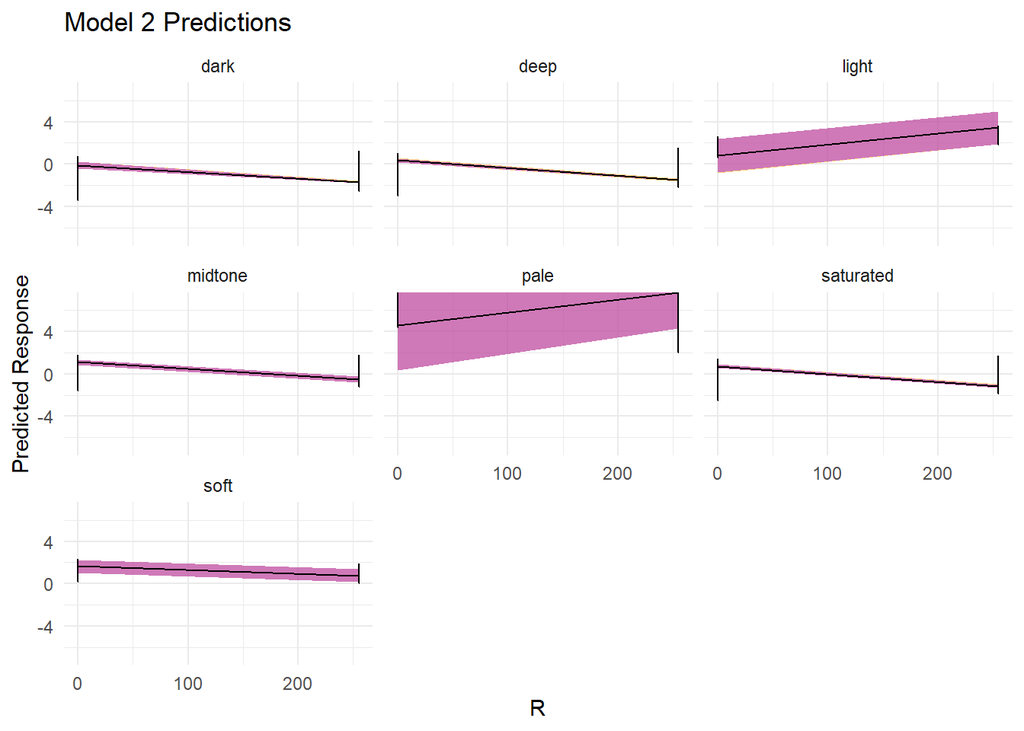

```r
pred_Model2 %>%
  ggplot(aes(x = R, y = pred)) +
  geom_ribbon(aes(ymin = pred_lwr, ymax = pred_upr), fill = "orange", alpha = 0.5) +
  geom_ribbon(aes(ymin = ci_lwr, ymax = ci_upr), fill = "purple", alpha = 0.5) +
  geom_line() +
  coord_cartesian(ylim = c(-7, 7)) +
  facet_wrap(~Lightness) +
  labs(title = "Model 2 Predictions",  # Adjust the title to match the model number
       x = "R",
       y = "Predicted Response") +
  theme_minimal()
```

## Part iid: Linear Regression - Train/tune with resampling

The resampling scheme is specified by the trainControl() function in caret. The type of scheme is controlled by the method argument. For k-fold cross-validation, the method argument must equal ‘cv’ and the number of folds is controlled by the number argument.

```r
my_ctrl <- trainControl(method = "cv", number = 5)
```

“RMSE” (Root Mean Squared Error) is the primary performance metric as it provides a good indication of how well the model’s predictions align with the observed data, giving equal weight to all errors

```r
my_metric <- "RMSE"
```

**Linear models**

Model 1: All categorical and continuous variables – linear additive

```r
mod1 <- train(
  logit_response ~ R + G + B + Hue + Lightness + Saturation,
  data = df_train,
  method = "lm",
  metric = my_metric,
  trControl = my_ctrl
)
mod1
```

```
## Linear Regression
##
## 835 samples
##   6 predictor
##
## No pre-processing
## Resampling: Cross-Validated (5 fold)
## Summary of sample sizes: 668, 668, 667, 669, 668
## Resampling results:
##
##   RMSE       Rsquared   MAE
##   0.0896478  0.9943322  0.06706989
##
## Tuning parameter 'intercept' was held constant at a value of TRUE
```

Model 2: Interaction of the categorical inputs with all continuous inputs main effects

```r
mod2 <- train(
  logit_response ~ (R + G + B + Hue) * (Lightness + Saturation),
  data = df_train,
  method = "lm",
  metric = my_metric,
  trControl = my_ctrl
)
mod2
```

```
## Linear Regression
##
## 835 samples
##   6 predictor
##
## No pre-processing
## Resampling: Cross-Validated (5 fold)
## Summary of sample sizes: 668, 669, 668, 668, 667
## Resampling results:
##
##   RMSE        Rsquared   MAE
##   0.06208476  0.9972943  0.04613305
##
## Tuning parameter 'intercept' was held constant at a value of TRUE
```

Model 3: Add categorical inputs to all main effect and all pairwise interactions of continuous inputs

```r
mod3 <- train(
  logit_response ~ (R + G + B + Hue)^2 + Lightness + Saturation,
  data = df_train,
  method = "lm",
  metric = my_metric,
  trControl = my_ctrl
)
mod3
```

```
## Linear Regression
##
## 835 samples
##   6 predictor
##
## No pre-processing
## Resampling: Cross-Validated (5 fold)
## Summary of sample sizes: 668, 668, 668, 667, 669
## Resampling results:
##
##   RMSE        Rsquared   MAE
##   0.08144482  0.9953126  0.06161192
##
## Tuning parameter 'intercept' was held constant at a value of TRUE
```

Model 4: Interaction of the categorical inputs with all main effect and all pairwise interactions of continuous inputs

```r
mod4 <- train(
  logit_response ~ (R + G + B + Hue)^2 * (Lightness + Saturation),
  data = df_train,
  method = "lm",
  metric = my_metric,
  trControl = my_ctrl
)
mod4
```

```
## Linear Regression
##
## 835 samples
##   6 predictor
##
## No pre-processing
## Resampling: Cross-Validated (5 fold)
## Summary of sample sizes: 668, 668, 669, 667, 668
## Resampling results:
##
##   RMSE        Rsquared   MAE
##   0.06112917  0.9973301  0.04140705
##
## Tuning parameter 'intercept' was held constant at a value of TRUE
```

**Best Performing Model: RMSE**

```r
results = resamples(list(fit_01 = mod1,
                         fit_02 = mod2,
                         fit_03 = mod3,
                         fit_04 = mod4))
summary_resampling <- summary(results, metric = my_metric)
summary_resampling
```

```
##
## Call:
## summary.resamples(object = results, metric = my_metric)
##
## Models: fit_01, fit_02, fit_03, fit_04
## Number of resamples: 5
##
## RMSE
##              Min.    1st Qu.     Median       Mean    3rd Qu.       Max. NA's
## fit_01 0.08552560 0.08653748 0.08677058 0.08964780 0.09142869 0.09797667    0
## fit_02 0.05525949 0.06013592 0.06326099 0.06208476 0.06472871 0.06703868    0
## fit_03 0.07618256 0.07971069 0.08216605 0.08144482 0.08376477 0.08540004    0
## fit_04 0.05094659 0.05239044 0.06165513 0.06112917 0.06641677 0.07423692    0
```

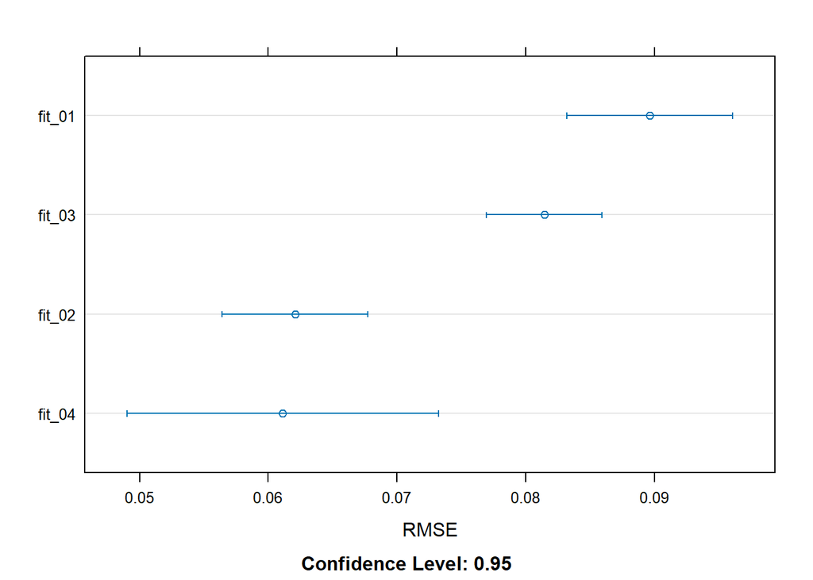

```r
dotplot_resampling <- dotplot(results, metric = my_metric)
dotplot_resampling
```

**Compare the coefficients between the top 3 models identified by the resampling procedure using the coefplot::multiplot() function.**

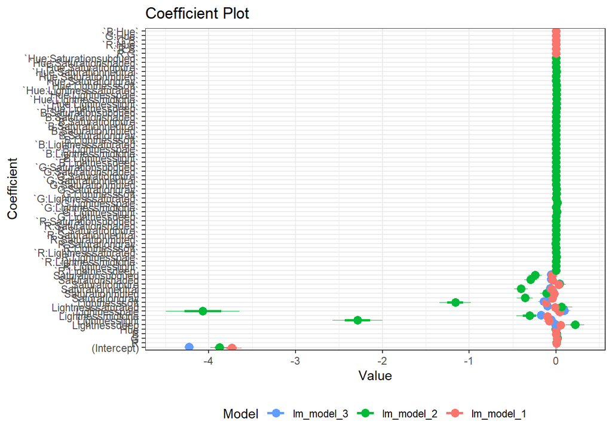

```r
lm_model_3 <- mod1$finalModel
lm_model_2 <- mod2$finalModel
lm_model_1 <- mod3$finalModel

coefplot::multiplot(lm_model_3, lm_model_2, lm_model_1, dodgeHeight = 0.35) +
  theme_bw() +
  theme(legend.position = 'bottom')
```

**Regularized regression with Elastic net**

```r
#Add categorical inputs to all main effect and all pairwise interactions of continuous inputs
set.seed(2001)
mod1_elastic_net <- train(
  logit_response ~ (R + G + B + Hue)^2 + Lightness + Saturation,
  data = df_train,
  method = "glmnet",
  tuneGrid = expand.grid(alpha = seq(0, 1, 0.1), lambda = seq(0.001, 0.1, 0.001)),
  trControl = my_ctrl
)
mod1_elastic_net
```

```
## glmnet
##
## 835 samples
##   6 predictor
##
## No pre-processing
## Resampling: Cross-Validated (5 fold)
## Summary of sample sizes: 668, 668, 669, 667, 668
## Resampling results across tuning parameters:
##
##   alpha  lambda  RMSE        Rsquared   MAE
##   0.0    0.001   0.11202054  0.9916562  0.08221674
##   0.0    0.002   0.11202054  0.9916562  0.08221674
##   0.0    0.003   0.11202054  0.9916562  0.08221674
##   0.0    0.004   0.11202054  0.9916562  0.08221674
##   0.0    0.005   0.11202054  0.9916562  0.08221674
##   0.0    0.006   0.11202054  0.9916562  0.08221674
##   0.0    0.007   0.11202054  0.9916562  0.08221674
##   0.0    0.008   0.11202054  0.9916562  0.08221674
##   0.0    0.009   0.11202054  0.9916562  0.08221674
##   0.0    0.010   0.11202054  0.9916562  0.08221674
##   0.0    0.011   0.11202054  0.9916562  0.08221674
##   0.0    0.012   0.11202054  0.9916562  0.08221674
##   0.0    0.013   0.11202054  0.9916562  0.08221674
##   0.0    0.014   0.11202054  0.9916562  0.08221674
##   0.0    0.015   0.11202054  0.9916562  0.08221674
##   0.0    0.016   0.11202054  0.9916562  0.08221674
##   0.0    0.017   0.11202054  0.9916562  0.08221674
##   0.0    0.018   0.11202054  0.9916562  0.08221674
##   0.0    0.019   0.11202054  0.9916562  0.08221674
##   0.0    0.020   0.11202054  0.9916562  0.08221674
##   0.0    0.021   0.11202054  0.9916562  0.08221674
##   0.0    0.022   0.11202054  0.9916562  0.08221674
##   0.0    0.023   0.11202054  0.9916562  0.08221674
##   0.0    0.024   0.11202054  0.9916562  0.08221674
##   0.0    0.025   0.11202054  0.9916562  0.08221674
##   0.0    0.026   0.11202054  0.9916562  0.08221674
##   0.0    0.027   0.11202054  0.9916562  0.08221674
##   0.0    0.028   0.11202054  0.9916562  0.08221674
##   0.0    0.029   0.11202054  0.9916562  0.08221674
```

[output cut: 1059 more lines]

```
##   1.0    0.089   0.14658795  0.9905838  0.10609014
##   1.0    0.090   0.14724458  0.9905800  0.10661160
##   1.0    0.091   0.14790561  0.9905761  0.10713307
##   1.0    0.092   0.14857099  0.9905722  0.10766028
##   1.0    0.093   0.14924065  0.9905682  0.10819045
##   1.0    0.094   0.14991466  0.9905642  0.10872381
##   1.0    0.095   0.15059257  0.9905602  0.10925719
##   1.0    0.096   0.15127431  0.9905561  0.10979288
##   1.0    0.097   0.15196010  0.9905520  0.11033666
##   1.0    0.098   0.15264990  0.9905479  0.11088324
##   1.0    0.099   0.15334365  0.9905437  0.11143198
##   1.0    0.100   0.15404130  0.9905394  0.11198552
##
## RMSE was used to select the optimal model using the smallest value.
## The final values used for the model were alpha = 0.3 and lambda = 0.001.
```

```r
#Interaction terms between the polynomial-transformed continuous variables and the categorical variables
set.seed(2001)
mod2_elastic_net <- train(
  logit_response ~ (poly(R, 2) + poly(G, 2) + poly(B, 2) + Hue) * (Lightness + Saturation),
  data = df_train,
  method = "glmnet",
  tuneGrid = expand.grid(alpha = seq(0, 1, 0.1), lambda = seq(0.001, 0.1, 0.001)),
  trControl = my_ctrl
)
mod2_elastic_net
```

```
## glmnet
##
## 835 samples
##   6 predictor
##
## No pre-processing
## Resampling: Cross-Validated (5 fold)
## Summary of sample sizes: 668, 668, 669, 667, 668
## Resampling results across tuning parameters:
##
##   alpha  lambda  RMSE        Rsquared   MAE
##   0.0    0.001   0.09595495  0.9938409  0.06526637
##   0.0    0.002   0.09595495  0.9938409  0.06526637
##   0.0    0.003   0.09595495  0.9938409  0.06526637
##   0.0    0.004   0.09595495  0.9938409  0.06526637
##   0.0    0.005   0.09595495  0.9938409  0.06526637
##   0.0    0.006   0.09595495  0.9938409  0.06526637
##   0.0    0.007   0.09595495  0.9938409  0.06526637
##   0.0    0.008   0.09595495  0.9938409  0.06526637
##   0.0    0.009   0.09595495  0.9938409  0.06526637
##   0.0    0.010   0.09595495  0.9938409  0.06526637
##   0.0    0.011   0.09595495  0.9938409  0.06526637
##   0.0    0.012   0.09595495  0.9938409  0.06526637
##   0.0    0.013   0.09595495  0.9938409  0.06526637
##   0.0    0.014   0.09595495  0.9938409  0.06526637
##   0.0    0.015   0.09595495  0.9938409  0.06526637
##   0.0    0.016   0.09595495  0.9938409  0.06526637
##   0.0    0.017   0.09595495  0.9938409  0.06526637
##   0.0    0.018   0.09595495  0.9938409  0.06526637
##   0.0    0.019   0.09595495  0.9938409  0.06526637
##   0.0    0.020   0.09595495  0.9938409  0.06526637
##   0.0    0.021   0.09595495  0.9938409  0.06526637
##   0.0    0.022   0.09595495  0.9938409  0.06526637
##   0.0    0.023   0.09595495  0.9938409  0.06526637
##   0.0    0.024   0.09595495  0.9938409  0.06526637
##   0.0    0.025   0.09595495  0.9938409  0.06526637
##   0.0    0.026   0.09595495  0.9938409  0.06526637
##   0.0    0.027   0.09595495  0.9938409  0.06526637
##   0.0    0.028   0.09595495  0.9938409  0.06526637
##   0.0    0.029   0.09595495  0.9938409  0.06526637
```

[output cut: 1059 more lines]

```
##   1.0    0.089   0.15193487  0.9900087  0.12409640
##   1.0    0.090   0.15290264  0.9899391  0.12487041
##   1.0    0.091   0.15387505  0.9898686  0.12564442
##   1.0    0.092   0.15485201  0.9897970  0.12641843
##   1.0    0.093   0.15583343  0.9897245  0.12719376
##   1.0    0.094   0.15681911  0.9896511  0.12797281
##   1.0    0.095   0.15780892  0.9895769  0.12875988
##   1.0    0.096   0.15880265  0.9895020  0.12954833
##   1.0    0.097   0.15980049  0.9894261  0.13033690
##   1.0    0.098   0.16080237  0.9893492  0.13112617
##   1.0    0.099   0.16180824  0.9892713  0.13191659
##   1.0    0.100   0.16281800  0.9891924  0.13271229
##
## RMSE was used to select the optimal model using the smallest value.
## The final values used for the model were alpha = 0.2 and lambda = 0.001.
```

```r
#Interaction terms between the polynomial-transformed continuous variables themselves
set.seed(2001)
mod3_elastic_net <- train(
   logit_response ~ poly(R, 2) * poly(G, 2) + poly(R, 2) * poly(B, 2) + poly(R, 2) * poly(Hue, 2) + poly(G, 2) * poly(B, 2) + poly(G, 2) * poly(Hue, 2) + poly(B, 2) * poly(Hue, 2),
  data = df_train,
  method = "glmnet",
  tuneGrid = expand.grid(alpha = seq(0, 1, 0.1), lambda = seq(0.001, 0.1, 0.001)),
  trControl = my_ctrl
)
mod3_elastic_net
```

```
## glmnet
##
## 835 samples
##   4 predictor
##
## No pre-processing
## Resampling: Cross-Validated (5 fold)
## Summary of sample sizes: 668, 668, 669, 667, 668
## Resampling results across tuning parameters:
##
##   alpha  lambda  RMSE        Rsquared   MAE
##   0.0    0.001   0.07926398  0.9964683  0.06044518
##   0.0    0.002   0.07926398  0.9964683  0.06044518
##   0.0    0.003   0.07926398  0.9964683  0.06044518
##   0.0    0.004   0.07926398  0.9964683  0.06044518
##   0.0    0.005   0.07926398  0.9964683  0.06044518
##   0.0    0.006   0.07926398  0.9964683  0.06044518
##   0.0    0.007   0.07926398  0.9964683  0.06044518
##   0.0    0.008   0.07926398  0.9964683  0.06044518
##   0.0    0.009   0.07926398  0.9964683  0.06044518
##   0.0    0.010   0.07926398  0.9964683  0.06044518
##   0.0    0.011   0.07926398  0.9964683  0.06044518
##   0.0    0.012   0.07926398  0.9964683  0.06044518
##   0.0    0.013   0.07926398  0.9964683  0.06044518
##   0.0    0.014   0.07926398  0.9964683  0.06044518
##   0.0    0.015   0.07926398  0.9964683  0.06044518
##   0.0    0.016   0.07926398  0.9964683  0.06044518
##   0.0    0.017   0.07926398  0.9964683  0.06044518
##   0.0    0.018   0.07926398  0.9964683  0.06044518
##   0.0    0.019   0.07926398  0.9964683  0.06044518
##   0.0    0.020   0.07926398  0.9964683  0.06044518
##   0.0    0.021   0.07926398  0.9964683  0.06044518
##   0.0    0.022   0.07926398  0.9964683  0.06044518
##   0.0    0.023   0.07926398  0.9964683  0.06044518
##   0.0    0.024   0.07926398  0.9964683  0.06044518
##   0.0    0.025   0.07926398  0.9964683  0.06044518
##   0.0    0.026   0.07926398  0.9964683  0.06044518
##   0.0    0.027   0.07926398  0.9964683  0.06044518
##   0.0    0.028   0.07926398  0.9964683  0.06044518
##   0.0    0.029   0.07926398  0.9964683  0.06044518
```

[output cut: 1059 more lines]

```
##   1.0    0.089   0.16452090  0.9869385  0.13068647
##   1.0    0.090   0.16522817  0.9869123  0.13128997
##   1.0    0.091   0.16594033  0.9868856  0.13189675
##   1.0    0.092   0.16665733  0.9868586  0.13250972
##   1.0    0.093   0.16737910  0.9868312  0.13312713
##   1.0    0.094   0.16810557  0.9868034  0.13374925
##   1.0    0.095   0.16883670  0.9867752  0.13437139
##   1.0    0.096   0.16957265  0.9867463  0.13499725
##   1.0    0.097   0.17031315  0.9867171  0.13562445
##   1.0    0.098   0.17105811  0.9866874  0.13625375
##   1.0    0.099   0.17180749  0.9866574  0.13688858
##   1.0    0.100   0.17256121  0.9866269  0.13753352
##
## RMSE was used to select the optimal model using the smallest value.
## The final values used for the model were alpha = 0.2 and lambda = 0.004.
```

**Best Performing Model:RMSE**

```r
ElasticNetresults = resamples(list(fit_E01 = mod1_elastic_net,
                                  fit_E02 = mod2_elastic_net,
                                  fit_E03 = mod3_elastic_net))
summary_elastic <- summary(ElasticNetresults, metric = my_metric)
summary_elastic
```

```
##
## Call:
## summary.resamples(object = ElasticNetresults, metric = my_metric)
##
## Models: fit_E01, fit_E02, fit_E03
## Number of resamples: 5
##
## RMSE
##               Min.    1st Qu.     Median       Mean    3rd Qu.       Max. NA's
## fit_E01 0.07555424 0.07804369 0.07933481 0.08115698 0.08204106 0.09081112    0
## fit_E02 0.04384074 0.04405491 0.04708162 0.04920973 0.05251972 0.05855168    0
## fit_E03 0.03810730 0.04083861 0.04495821 0.04461185 0.04631647 0.05283867    0
```

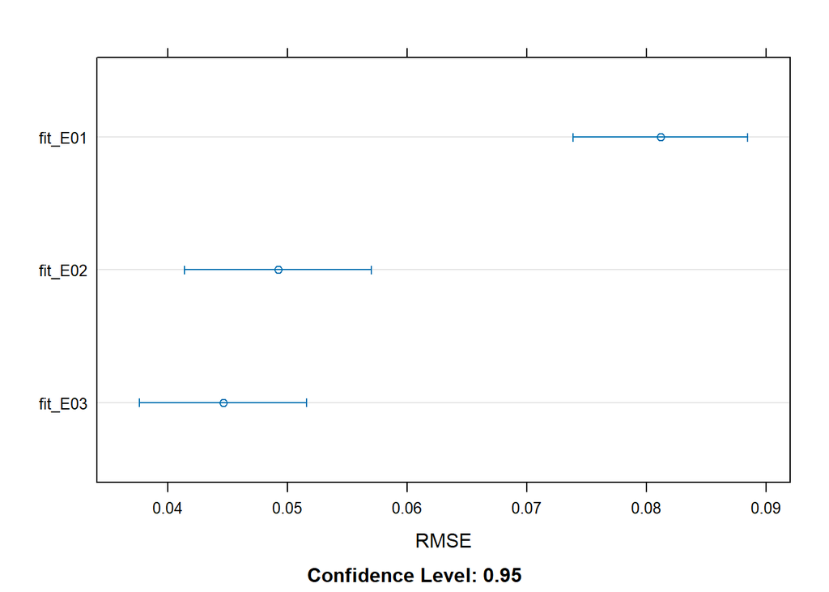

```r
dotplot_resampling_EN<- dotplot(ElasticNetresults, metric = my_metric)
dotplot_resampling_EN
```

The model with the lowest RMSE is fit_E03.

**Neural Network**

```r
#Add categorical inputs to all main effect and all pairwise interactions of continuous inputs
set.seed(2001)
mod_nn1 <- train(
  logit_response ~ (R + G + B + Hue)^2 + Lightness + Saturation,
  data = df_train,
  method = "nnet",
  trControl = my_ctrl,
  tuneGrid = expand.grid(size = c(1, 5, 10), decay = c(0, 0.001, 0.01))
)
mod_nn1
```

```
## Neural Network
##
## 835 samples
##   6 predictor
##
## No pre-processing
## Resampling: Cross-Validated (5 fold)
## Summary of sample sizes: 668, 668, 669, 667, 668
## Resampling results across tuning parameters:
##
##   size  decay  RMSE      Rsquared   MAE
##    1    0.000  1.188177        NaN  1.0114827
##    1    0.001  1.181393  0.1767723  0.9960954
##    1    0.010  1.135726  0.4510111  0.9340351
##    5    0.000  1.188177        NaN  1.0114827
##    5    0.001  1.111449  0.3073963  0.8993328
##    5    0.010  1.120805  0.2897960  0.9111436
##   10    0.000  1.188177        NaN  1.0114827
##   10    0.001  1.146688  0.2468208  0.9384571
##   10    0.010  1.060280  0.4419627  0.8177202
##
## RMSE was used to select the optimal model using the smallest value.
## The final values used for the model were size = 10 and decay = 0.01.
```

```r
#Interaction terms between the polynomial-transformed continuous variables and the categorical variables
set.seed(2001)
mod_nn2 <- train(
  logit_response ~ (poly(R, 2) + poly(G, 2) + poly(B, 2) + Hue) * (Lightness + Saturation),
  data = df_train,
  method = "nnet",
  trControl = my_ctrl,
  tuneGrid = expand.grid(size = c(1, 5, 10), decay = c(0, 0.001, 0.01))
)
mod_nn2
```

```
## Neural Network
##
## 835 samples
##   6 predictor
##
## No pre-processing
## Resampling: Cross-Validated (5 fold)
## Summary of sample sizes: 668, 668, 669, 667, 668
## Resampling results across tuning parameters:
##
##   size  decay  RMSE       Rsquared   MAE
##    1    0.000  1.1881768        NaN  1.0114827
##    1    0.001  1.0050234  0.5547709  0.7371585
##    1    0.010  0.9909078  0.6149548  0.7184579
##    5    0.000  1.1881768        NaN  1.0114827
##    5    0.001  0.9925751  0.6124987  0.7235918
##    5    0.010  0.9892808  0.6344528  0.7164080
##   10    0.000        NaN        NaN        NaN
##   10    0.001        NaN        NaN        NaN
##   10    0.010        NaN        NaN        NaN
##
## RMSE was used to select the optimal model using the smallest value.
## The final values used for the model were size = 5 and decay = 0.01.
```

```r
#Interaction terms between the polynomial-transformed continuous variables themselves
set.seed(2001)
mod_nn3 <- train(
  logit_response ~ poly(R, 2) * poly(G, 2) + poly(R, 2) * poly(B, 2) + poly(R, 2) * poly(Hue, 2) + poly(G, 2) * poly(B, 2) + poly(G, 2) * poly(Hue, 2) + poly(B, 2) * poly(Hue, 2),
  data = df_train,
  method = "nnet",
  trControl = my_ctrl,
  tuneGrid = expand.grid(size = c(1, 5, 10), decay = c(0, 0.001, 0.01))
)
mod_nn3
```

```
## Neural Network
##
## 835 samples
##   4 predictor
##
## No pre-processing
## Resampling: Cross-Validated (5 fold)
## Summary of sample sizes: 668, 668, 669, 667, 668
## Resampling results across tuning parameters:
##
##   size  decay  RMSE       Rsquared   MAE
##    1    0.000  1.1881768        NaN  1.0114827
##    1    0.001  0.9671833  0.7370863  0.6550115
##    1    0.010  0.9680421  0.7483511  0.6546713
##    5    0.000  1.1881768        NaN  1.0114827
##    5    0.001  1.0108750  0.7826718  0.7275167
##    5    0.010  0.9676916  0.7488316  0.6535573
##   10    0.000  1.1881768        NaN  1.0114827
##   10    0.001  1.1447838  0.9302645  0.9396708
##   10    0.010  0.9676936  0.7481190  0.6535095
##
## RMSE was used to select the optimal model using the smallest value.
## The final values used for the model were size = 1 and decay = 0.001.
```

**Best Performing Model:RMSE**

```r
NNresults = resamples(list(fit_N01 = mod_nn1,
                                  fit_N02 = mod_nn2,
                                  fit_N03 = mod_nn3))
summary_nn <- summary(NNresults, metric = my_metric)
summary_nn
```

```
##
## Call:
## summary.resamples(object = NNresults, metric = my_metric)
##
## Models: fit_N01, fit_N02, fit_N03
## Number of resamples: 5
##
## RMSE
##              Min.   1st Qu.    Median      Mean   3rd Qu.     Max. NA's
## fit_N01 1.0058399 1.0318221 1.0463229 1.0602795 1.0502412 1.167172    0
## fit_N02 0.9457384 0.9659247 0.9860319 0.9892808 0.9970158 1.051693    0
## fit_N03 0.9203901 0.9477517 0.9623484 0.9671833 0.9703065 1.035120    0
```

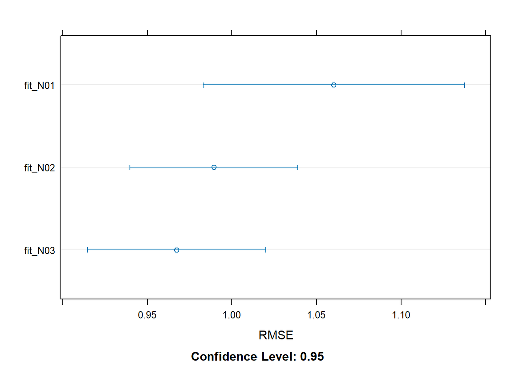

```r
dotplot_resamplingNN <- dotplot(NNresults, metric = my_metric)
dotplot_resamplingNN
```

The model with the lowest RMSE is fit_N03.

**Random forest**

```r
# Add categorical inputs to all main effect and all pairwise interactions of continuous inputs
set.seed(2001)
mod_rf1 <- train(
  logit_response ~ (R + G + B + Hue)^2 + Lightness + Saturation,
  data = df_train,
  method = "rf",
  trControl = my_ctrl
)
mod_rf1
```

```
## Random Forest
##
## 835 samples
##   6 predictor
##
## No pre-processing
## Resampling: Cross-Validated (5 fold)
## Summary of sample sizes: 668, 668, 669, 667, 668
## Resampling results across tuning parameters:
##
##   mtry  RMSE        Rsquared   MAE
##    2    0.12439007  0.9913651  0.08973495
##   12    0.05641018  0.9978103  0.04038118
##   22    0.06901763  0.9966562  0.05035531
##
## RMSE was used to select the optimal model using the smallest value.
## The final value used for the model was mtry = 12.
```

```r
# Interaction terms between the polynomial-transformed continuous variables and the categorical variables
set.seed(2001)
mod_rf2 <- train(
  logit_response ~ (poly(R, 2) + poly(G, 2) + poly(B, 2) + Hue) * (Lightness + Saturation),
  data = df_train,
  method = "rf",
  trControl = my_ctrl
)
mod_rf2
```

```
## Random Forest
##
## 835 samples
##   6 predictor
##
## No pre-processing
## Resampling: Cross-Validated (5 fold)
## Summary of sample sizes: 668, 668, 669, 667, 668
## Resampling results across tuning parameters:
##
##   mtry  RMSE        Rsquared   MAE
##     2   0.30088638  0.9567930  0.22233465
##    52   0.08022524  0.9955933  0.05956455
##   103   0.09357454  0.9938213  0.06828008
##
## RMSE was used to select the optimal model using the smallest value.
## The final value used for the model was mtry = 52.
```

```r
# Interaction terms between the polynomial-transformed continuous variables and the categorical variables
set.seed(2001)
mod_rf3 <- train(
    logit_response ~ poly(R, 2) * poly(G, 2) + poly(R, 2) * poly(B, 2) + poly(R, 2) * poly(Hue, 2) + poly(G, 2) * poly(B, 2) + poly(G, 2) * poly(Hue, 2) + poly(B, 2) * poly(Hue, 2),
  data = df_train,
  method = "rf",
  trControl = my_ctrl
)
mod_rf3
```

```
## Random Forest
##
## 835 samples
##   4 predictor
##
## No pre-processing
## Resampling: Cross-Validated (5 fold)
## Summary of sample sizes: 668, 668, 669, 667, 668
## Resampling results across tuning parameters:
##
##   mtry  RMSE        Rsquared   MAE
##    2    0.12088142  0.9928958  0.08143274
##   17    0.06564813  0.9970808  0.04714214
##   32    0.07634287  0.9959532  0.05404968
##
## RMSE was used to select the optimal model using the smallest value.
## The final value used for the model was mtry = 17.
```

**Best Performing Model:RMSE**

```r
RFresults = resamples(list(fit_RF01 = mod_rf1,
                                  fit_RF02 = mod_rf2,
                                  fit_RF03 = mod_rf3))
summary_RF <- summary(RFresults, metric = my_metric)
summary_RF
```

```
##
## Call:
## summary.resamples(object = RFresults, metric = my_metric)
##
## Models: fit_RF01, fit_RF02, fit_RF03
## Number of resamples: 5
##
## RMSE
##                Min.    1st Qu.     Median       Mean    3rd Qu.       Max. NA's
## fit_RF01 0.05231084 0.05409325 0.05707160 0.05641018 0.05893637 0.05963883    0
## fit_RF02 0.06729856 0.07931965 0.08092659 0.08022524 0.08275911 0.09082225    0
## fit_RF03 0.05684517 0.06109422 0.06656824 0.06564813 0.06752673 0.07620631    0
```

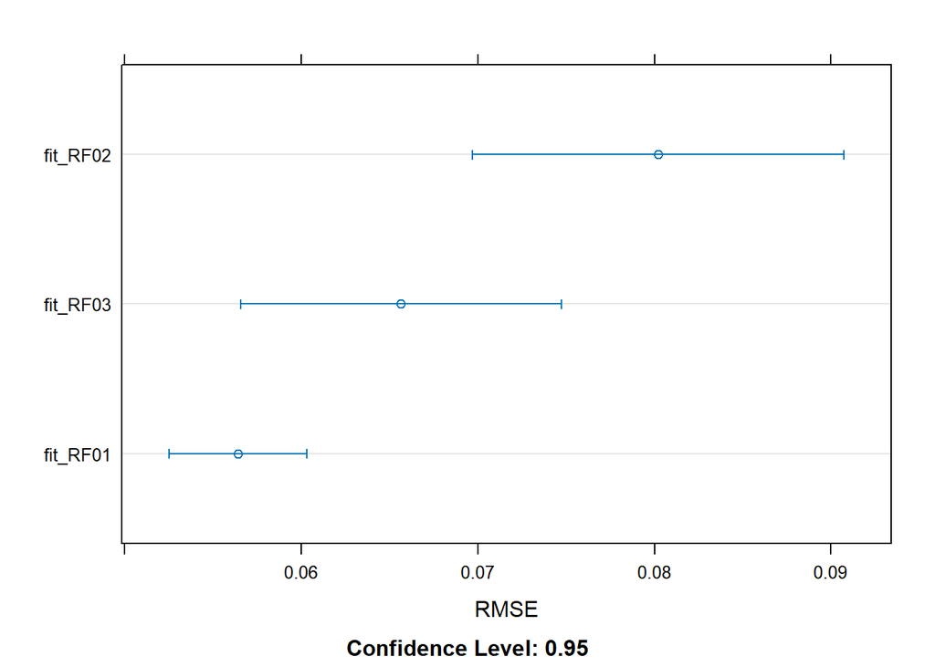

```r
dotplot_resamplingRF <- dotplot(RFresults, metric = my_metric)
dotplot_resamplingRF
```

The Model with lowest RMSE is fit_RF01.

**Gradient boosted tree**

```r
#Add categorical inputs to all main effect and all pairwise interactions of continuous inputs
library(gbm)
set.seed(2001)
mod_gbt1 <- train(
  logit_response ~ (R + G + B + Hue)^2 + Lightness + Saturation,
  data = df_train,
  method = "gbm",
  trControl = my_ctrl,
  verbose = FALSE
)
mod_gbt1
```

```
## Stochastic Gradient Boosting
##
## 835 samples
##   6 predictor
##
## No pre-processing
## Resampling: Cross-Validated (5 fold)
## Summary of sample sizes: 668, 668, 669, 667, 668
## Resampling results across tuning parameters:
##
##   interaction.depth  n.trees  RMSE        Rsquared   MAE
##   1                   50      0.14643501  0.9881360  0.10654465
##   1                  100      0.10562612  0.9920359  0.07777095
##   1                  150      0.10023834  0.9928161  0.07414919
##   2                   50      0.10074616  0.9930319  0.07332520
##   2                  100      0.08178994  0.9952455  0.06180640
##   2                  150      0.07431220  0.9960647  0.05655594
##   3                   50      0.08655847  0.9947205  0.06469506
##   3                  100      0.07040685  0.9964524  0.05321811
##   3                  150      0.06517572  0.9969690  0.04900480
##
## Tuning parameter 'shrinkage' was held constant at a value of 0.1
##
## Tuning parameter 'n.minobsinnode' was held constant at a value of 10
## RMSE was used to select the optimal model using the smallest value.
## The final values used for the model were n.trees = 150, interaction.depth =
##  3, shrinkage = 0.1 and n.minobsinnode = 10.
```

```r
#Interaction terms between the polynomial-transformed continuous variables and the categorical variables
set.seed(2001)
mod_gbt2 <- train(
  logit_response ~ (poly(R, 2) + poly(G, 2) + poly(B, 2) + Hue) * (Lightness + Saturation),
  data = df_train,
  method = "gbm",
  trControl = my_ctrl,
  verbose = FALSE
)
mod_gbt2
```

```
## Stochastic Gradient Boosting
##
## 835 samples
##   6 predictor
##
## No pre-processing
## Resampling: Cross-Validated (5 fold)
## Summary of sample sizes: 668, 668, 669, 667, 668
## Resampling results across tuning parameters:
##
##   interaction.depth  n.trees  RMSE        Rsquared   MAE
##   1                   50      0.14931042  0.9877030  0.11165008
##   1                  100      0.10064797  0.9928167  0.07720934
##   1                  150      0.09071203  0.9941596  0.06984104
##   2                   50      0.09893392  0.9934252  0.07398864
##   2                  100      0.07569649  0.9959305  0.05707809
##   2                  150      0.06963050  0.9965542  0.05274556
##   3                   50      0.08338519  0.9951918  0.06458286
##   3                  100      0.06678530  0.9968446  0.05175695
##   3                  150      0.06242806  0.9972495  0.04846005
##
## Tuning parameter 'shrinkage' was held constant at a value of 0.1
##
## Tuning parameter 'n.minobsinnode' was held constant at a value of 10
## RMSE was used to select the optimal model using the smallest value.
## The final values used for the model were n.trees = 150, interaction.depth =
##  3, shrinkage = 0.1 and n.minobsinnode = 10.
```

```r
#Interaction terms between the polynomial-transformed continuous variables themselves
set.seed(2001)
mod_gbt3 <- train(
  logit_response ~ poly(R, 2) * poly(G, 2) + poly(R, 2) * poly(B, 2) + poly(R, 2) * poly(Hue, 2) + poly(G, 2) * poly(B, 2) + poly(G, 2) * poly(Hue, 2) + poly(B, 2) * poly(Hue, 2),
  data = df_train,
  method = "gbm",
  trControl = my_ctrl,
  verbose = FALSE
)
mod_gbt3
```

```
## Stochastic Gradient Boosting
##
## 835 samples
##   4 predictor
##
## No pre-processing
## Resampling: Cross-Validated (5 fold)
## Summary of sample sizes: 668, 668, 669, 667, 668
## Resampling results across tuning parameters:
##
##   interaction.depth  n.trees  RMSE        Rsquared   MAE
##   1                   50      0.14414328  0.9889132  0.10928307
##   1                  100      0.09257926  0.9939906  0.07277685
##   1                  150      0.08368334  0.9950396  0.06593555
##   2                   50      0.08779033  0.9948744  0.06681335
##   2                  100      0.06717247  0.9967648  0.05176152
##   2                  150      0.06411937  0.9970647  0.04909161
##   3                   50      0.08202702  0.9953424  0.06215560
##   3                  100      0.06834245  0.9966955  0.05265027
##   3                  150      0.06511203  0.9970025  0.05055878
##
## Tuning parameter 'shrinkage' was held constant at a value of 0.1
##
## Tuning parameter 'n.minobsinnode' was held constant at a value of 10
## RMSE was used to select the optimal model using the smallest value.
## The final values used for the model were n.trees = 150, interaction.depth =
##  2, shrinkage = 0.1 and n.minobsinnode = 10.
```

**Best Performing Model:RMSE**

```r
GBTresults = resamples(list(fit_GBT01 = mod_gbt1,
                                  fit_GBT02 = mod_gbt2,
                                  fit_GBT03 = mod_gbt3))
summary_GBT <- summary(GBTresults, metric = my_metric)
summary_GBT
```

```
##
## Call:
## summary.resamples(object = GBTresults, metric = my_metric)
##
## Models: fit_GBT01, fit_GBT02, fit_GBT03
## Number of resamples: 5
##
## RMSE
##                 Min.    1st Qu.     Median       Mean    3rd Qu.       Max.
## fit_GBT01 0.05900511 0.06002661 0.06444461 0.06517572 0.07079771 0.07160455
## fit_GBT02 0.05303108 0.05800143 0.06024222 0.06242806 0.06766424 0.07320135
## fit_GBT03 0.05719401 0.05926212 0.06189079 0.06411937 0.07053048 0.07171943
##           NA's
## fit_GBT01    0
## fit_GBT02    0
## fit_GBT03    0
```

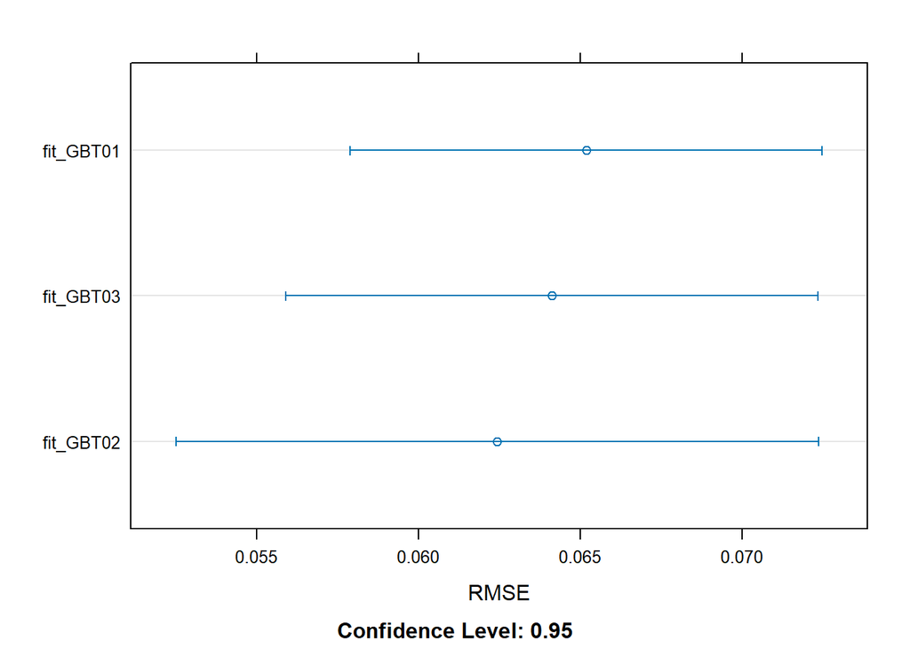

```r
dotplot_resamplingGBT <- dotplot(GBTresults, metric = my_metric)
dotplot_resamplingGBT
```

The model with the lowest RMSE is fit_GBT02.

**Support Vector Machine (SVM)**

```r
#Add categorical inputs to all main effect and all pairwise interactions of continuous inputs
library(kernlab)
set.seed(2001)
mod_svm1 <- train(
  logit_response ~ (R + G + B + Hue)^2 + Lightness + Saturation,
  data = df_train,
  method = "svmRadial",
  trControl = my_ctrl,
  tuneGrid = expand.grid(sigma = 0.1, C = 1)
)
mod_svm1
```

```
## Support Vector Machines with Radial Basis Function Kernel
##
## 835 samples
##   6 predictor
##
## No pre-processing
## Resampling: Cross-Validated (5 fold)
## Summary of sample sizes: 668, 668, 669, 667, 668
## Resampling results:
##
##   RMSE       Rsquared   MAE
##   0.1393793  0.9866814  0.1050779
##
## Tuning parameter 'sigma' was held constant at a value of 0.1
## Tuning
##  parameter 'C' was held constant at a value of 1
```

```r
#Interaction terms between the polynomial-transformed continuous variables and the categorical variables

set.seed(2001)
mod_svm2 <- train(
  logit_response ~ (poly(R, 2) + poly(G, 2) + poly(B, 2) + Hue) * (Lightness + Saturation),
  data = df_train,
  method = "svmRadial",
  trControl = my_ctrl,
  tuneGrid = expand.grid(sigma = 0.1, C = 1)
)
mod_svm2
```

```
## Support Vector Machines with Radial Basis Function Kernel
##
## 835 samples
##   6 predictor
##
## No pre-processing
## Resampling: Cross-Validated (5 fold)
## Summary of sample sizes: 668, 668, 669, 667, 668
## Resampling results:
##
##   RMSE     Rsquared   MAE
##   0.62757  0.7759737  0.4505492
##
## Tuning parameter 'sigma' was held constant at a value of 0.1
## Tuning
##  parameter 'C' was held constant at a value of 1
```

```r
#Interaction terms between the polynomial-transformed continuous variables themselves

set.seed(2001)
mod_svm3 <- train(
   logit_response ~ poly(R, 2) * poly(G, 2) + poly(R, 2) * poly(B, 2) + poly(R, 2) * poly(Hue, 2) + poly(G, 2) * poly(B, 2) + poly(G, 2) * poly(Hue, 2) + poly(B, 2) * poly(Hue, 2),
  data = df_train,
  method = "svmRadial",
  trControl = my_ctrl,
  tuneGrid = expand.grid(sigma = 0.1, C = 1)
)
mod_svm3
```

```
## Support Vector Machines with Radial Basis Function Kernel
##
## 835 samples
##   4 predictor
##
## No pre-processing
## Resampling: Cross-Validated (5 fold)
## Summary of sample sizes: 668, 668, 669, 667, 668
## Resampling results:
##
##   RMSE      Rsquared   MAE
##   0.233885  0.9671465  0.1307934
##
## Tuning parameter 'sigma' was held constant at a value of 0.1
## Tuning
##  parameter 'C' was held constant at a value of 1
```

**Best Performing Model: RMSE**

```r
SVMresults = resamples(list(fit_SVM01 = mod_svm1,
                                  fit_SVM02 = mod_svm2,
                                  fit_SVM03 = mod_svm3))
summary_SVM <- summary(SVMresults, metric = my_metric)
summary_SVM
```

```
##
## Call:
## summary.resamples(object = SVMresults, metric = my_metric)
##
## Models: fit_SVM01, fit_SVM02, fit_SVM03
## Number of resamples: 5
##
## RMSE
##                Min.   1st Qu.    Median      Mean   3rd Qu.      Max. NA's
## fit_SVM01 0.1330285 0.1346792 0.1393165 0.1393793 0.1443816 0.1454906    0
## fit_SVM02 0.5780197 0.6014646 0.6351030 0.6275700 0.6420910 0.6811719    0
## fit_SVM03 0.1865301 0.2164641 0.2410090 0.2338850 0.2430514 0.2823702    0
```

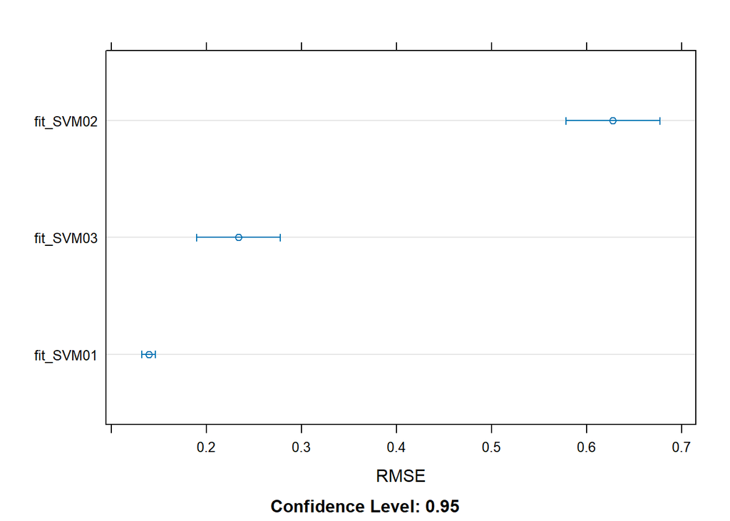

```r
dotplot_resamplingSVM <- dotplot(SVMresults, metric = my_metric)
dotplot_resamplingSVM
```

The model with lowest RMSE is fit_SVM01.

**k-Nearest Neighbors (k-NN)**

```r
#Add categorical inputs to all main effect and all pairwise interactions of continuous inputs
set.seed(2001)
mod_knn1 <- train(logit_response ~ (R + G + B + Hue)^2 + Lightness + Saturation,
  data = df_train,
  method = "knn",
  trControl = my_ctrl,
  tuneGrid = expand.grid(k = c(5, 10, 15))
)
mod_knn1
```

```
## k-Nearest Neighbors
##
## 835 samples
##   6 predictor
##
## No pre-processing
## Resampling: Cross-Validated (5 fold)
## Summary of sample sizes: 668, 668, 669, 667, 668
## Resampling results across tuning parameters:
##
##   k   RMSE       Rsquared   MAE
##    5  0.1119758  0.9912669  0.07474353
##   10  0.1234936  0.9894180  0.08410033
##   15  0.1332045  0.9876157  0.08966155
##
## RMSE was used to select the optimal model using the smallest value.
## The final value used for the model was k = 5.
```

```r
#  Interaction terms between the polynomial-transformed continuous variables and the categorical variables
set.seed(2001)
mod_knn2 <- train(
  logit_response ~ (poly(R, 2) + poly(G, 2) + poly(B, 2) + Hue) * (Lightness + Saturation),
  data = df_train,
  method = "knn",
  trControl = my_ctrl,
  tuneGrid = expand.grid(k = c(5, 10, 15))
)
mod_knn2
```

```
## k-Nearest Neighbors
##
## 835 samples
##   6 predictor
##
## No pre-processing
## Resampling: Cross-Validated (5 fold)
## Summary of sample sizes: 668, 668, 669, 667, 668
## Resampling results across tuning parameters:
##
##   k   RMSE       Rsquared   MAE
##    5  0.4733820  0.8398910  0.3300289
##   10  0.5990358  0.7594664  0.4434429
##   15  0.7076346  0.6949302  0.5475218
##
## RMSE was used to select the optimal model using the smallest value.
## The final value used for the model was k = 5.
```

```r
# Interaction terms between the polynomial-transformed continuous variables themselves

set.seed(2001)
mod_knn3 <- train(
  logit_response ~ poly(R, 2) * poly(G, 2) + poly(R, 2) * poly(B, 2) + poly(R, 2) * poly(Hue, 2) + poly(G, 2) * poly(B, 2) + poly(G, 2) * poly(Hue, 2) + poly(B, 2) * poly(Hue, 2),
  data = df_train,
  method = "knn",
  trControl = my_ctrl,
  tuneGrid = expand.grid(k = c(5, 10, 15))
)
mod_knn3
```

```
## k-Nearest Neighbors
##
## 835 samples
##   4 predictor
##
## No pre-processing
## Resampling: Cross-Validated (5 fold)
## Summary of sample sizes: 668, 668, 669, 667, 668
## Resampling results across tuning parameters:
##
##   k   RMSE       Rsquared   MAE
##    5  0.1141925  0.9908479  0.08430623
##   10  0.1243202  0.9893777  0.09009142
##   15  0.1408400  0.9866653  0.10043404
##
## RMSE was used to select the optimal model using the smallest value.
## The final value used for the model was k = 5.
```

**Best Performing Model: RMSE**

```r
KNNresults = resamples(list(fit_KNN01 = mod_knn1,
                                  fit_KNN02 = mod_knn2,
                                  fit_KNN03 = mod_knn3))
summary_KNN <- summary(KNNresults, metric = my_metric)
summary_KNN
```

```
##
## Call:
## summary.resamples(object = KNNresults, metric = my_metric)
##
## Models: fit_KNN01, fit_KNN02, fit_KNN03
## Number of resamples: 5
##
## RMSE
##                 Min.   1st Qu.    Median      Mean   3rd Qu.      Max. NA's
## fit_KNN01 0.09751687 0.1061591 0.1151074 0.1119758 0.1162924 0.1248031    0
## fit_KNN02 0.40161288 0.4421564 0.4856026 0.4733820 0.5108861 0.5266522    0
## fit_KNN03 0.10358287 0.1050991 0.1117648 0.1141925 0.1172906 0.1332250    0
```

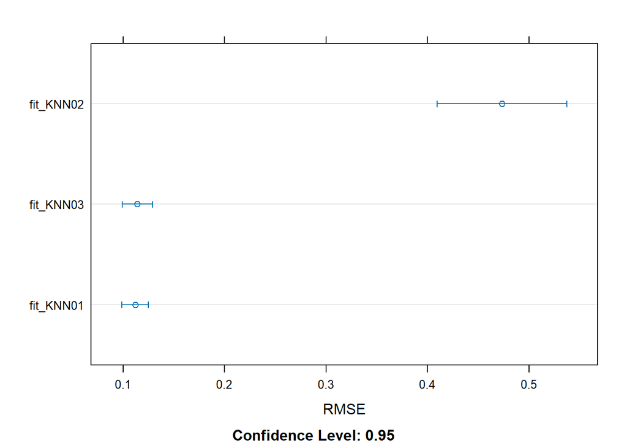

```r
dotplot_resamplingKNN<- dotplot(KNNresults, metric = my_metric)
dotplot_resamplingKNN
```

The model with the lowest RMSE is fit_KNN01.